# Data Camp Insights

davegoblue

June 1, 2018

```r
library(tidyverse)
```

## Background and Overview

DataCamp offer interactive courses related to R Programming. While some is review, it is helpful to see other perspectives on material. As well, DataCamp has some interesting materials on packages that I want to learn better (ggplot2, dplyr, ggvis, etc.). This document summarizes a few key insights from:

This document is currently split between _v003 and _v003_a and _v003_b and _v003_c due to the need to keep the number of DLL that it opens below the hard-coded maximum. This introductory section needs to be re-written, and the contents consolidated, at a future date.

- R Programming (Introductory R, Intermediate R, Writing Functions in R, Object Oriented Programming in R, Introduction to Tidyverse)
- Importing and Cleaning Data (Cleaning Data in R, Importing Data in to R)
- Data Manipulation (dplyr, data.table, xts/zoo, dplyr joins, cases for EDA/Time Series/Pitch Data)
- Data Visualization (base, ggplot2 parts I/II/III, ggvis, geospatial)
- Statistics (8 refresher modules)
- Machine Learning (3 modules + 1 text mining case)
- R Studio (2 parts) and R Markdown (1 module)

The original DataCamp_Insights_v001 and DataCamp_Insights_v002 documents have been split for this document:

- This DataCamp_Insights_v003 document contains evolving sections on R Programming, Machine Learning, and RStudio / R Markdown
- Importing and Cleaning Data components have been moved to DataCamp_ImportClean_v002
- Data Manipulation components have been moved to DataCamp_DataManipulation_v002
- Visualization components have been moved to DataCamp_Visualization_v002
- Statistics components have been moved to DataCamp_Statistics_v002

### *Hierarchical and Mixed Effects Models*

Chapter 1 - Overview and Introduction

What is a hierarchical model?

- Hierarchical data is nested within itself, and can be analyzed using the lme package
  - Example of students in a classroom - may not all be independent of each other due to teacher quality, building conditions, etc.
  - Hierarchical models can help with pooling means across small sample sizes
  - Repeated measurements (test scores each year) are also a common example of data that are not truly independent
- Hierarchical models can include nested models and multi-level models
- Regression frameworks can include pool information and random effects (vs. fixed effects) and mixed-effects and linear mixed-effects
- Repeated sampling can have repeated measures modeling

Parts of a regression:

- Linear regression and linear model can be used interchangeably for this course - epsilon is the error term, assumed to be normal with zero mean and constant variance
- The linear model in R is closely related to analysis of variance (ANOVA)
  - lm (y ~ x, myData)
  - anova( lm (y ~ x, myData) )
- The most basic regression has an intercept, a slope, a single predictor, and an error term
  - The concept can be extended to multiple regression with additional predictors
- There are some limitations to the multiple regression approach
  - Parameter estimates can be very sensitive to other variables - Simpson’s paradox and the like
  - Need to note that the regression coefficient is “after controlling for . . .” (all the other variables)
  - Interaction terms can be important as well
- Regressions in R for an intercept for every group are called as lm(y ~ x - 1)
- The interaction term x1*x2 is the same as x1 + x2 + x1:x2

Random effects in regression:

- Nested relationships tend to be hierarchical in nature - students are part of classes are part of schools and the like
  - Mathematically, this is referred to as a mapping among the distributions
- The algebraic representation is that y ~ B*x + eps, with B ~ N(mu, sigma**2)
  - library(lme4) is the best packages for this in R
  - lme4::lmer(y ~ x + (1|randomGroup), data=myData)
  - lme4::lmer(y ~ x + (randomSlope|randomGroup), data=myData)

School data:

- Appliciation of multi-level models to school data - influence of sex, teacher training, plotting parameter estmates

Example code includes:

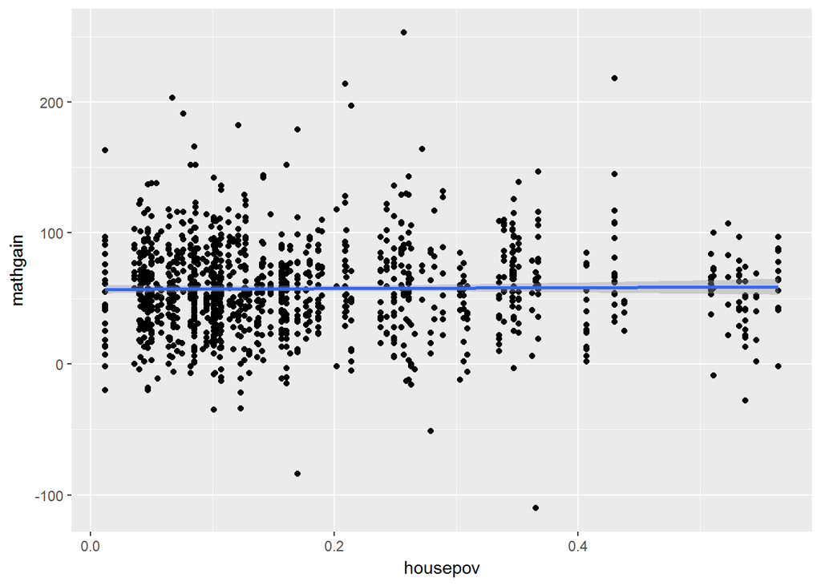

```r
rawStudent <- read.csv("./RInputFiles/classroom.csv")

studentData <- rawStudent %>%
    mutate(sex=factor(sex, labels=c("male", "female")), minority=factor(minority, labels=c("no", "yes")))


# Plot the data
ggplot(data = studentData, aes(x = housepov, y = mathgain)) +
    geom_point() +
    geom_smooth(method = 'lm')
```

```r
# Fit a linear model
summary( lm(mathgain ~ housepov , data = studentData))
```

```
##
## Call:
## lm(formula = mathgain ~ housepov, data = studentData)
##
## Residuals:
##      Min       1Q   Median       3Q      Max
## -168.226  -22.222   -1.306   19.763  195.156
##
## Coefficients:
##             Estimate Std. Error t value Pr(>|t|)
## (Intercept)   56.937      1.674   34.02   <2e-16 ***
## housepov       3.531      7.515    0.47    0.639
## ---
## Signif. codes:  0 '***' 0.001 '**' 0.01 '*' 0.05 '.' 0.1 ' ' 1
##
## Residual standard error: 34.63 on 1188 degrees of freedom
## Multiple R-squared:  0.0001858,  Adjusted R-squared:  -0.0006558
## F-statistic: 0.2208 on 1 and 1188 DF,  p-value: 0.6385
```

```r
# I have aggregated the data for you into two new datasets at the classroom- and school-levels (As a side note, if you want to learn how to aggregate data, the dplyr or data.table courses teach these skills)
# We will also compare the model outputs across all three outputs
# Note: how we aggregate the data is important
# I aggregated the data by taking the mean across the student data (in pseudo-code: mean(mathgain) by school or mean(mathgain) by classroom),
# but another reasonable method for aggregating the data would be to aggregate by classroom first and school second

classData <- studentData %>%
    group_by(schoolid, classid) %>%
    summarize_at(vars(mathgain, mathprep, housepov, yearstea), mean, na.rm=TRUE)
str(classData)
```

```
## Classes 'grouped_df', 'tbl_df', 'tbl' and 'data.frame':  312 obs. of  6 variables:
##  $ schoolid: int  1 1 2 2 2 3 3 3 3 4 ...
##  $ classid : int  160 217 197 211 307 11 137 145 228 48 ...
##  $ mathgain: num  65.7 57.4 49.5 69 68.8 ...
##  $ mathprep: num  2 3.25 2.5 2.33 2.3 3.83 2.25 3 2.17 2 ...
##  $ housepov: num  0.082 0.082 0.082 0.082 0.082 0.086 0.086 0.086 0.086 0.365 ...
##  $ yearstea: num  1 2 1 2 12.5 ...
##  - attr(*, "vars")= chr "schoolid"
##  - attr(*, "drop")= logi TRUE
```

```r
schoolData <- studentData %>%
    group_by(schoolid) %>%
    summarize_at(vars(mathgain, mathprep, housepov, yearstea), mean, na.rm=TRUE)
str(schoolData)
```

```
## Classes 'tbl_df', 'tbl' and 'data.frame':    107 obs. of  5 variables:
##  $ schoolid: int  1 2 3 4 5 6 7 8 9 10 ...
##  $ mathgain: num  59.6 65 88.9 35.2 60.2 ...
##  $ mathprep: num  2.91 2.35 2.95 2 3.75 ...
##  $ housepov: num  0.082 0.082 0.086 0.365 0.511 0.044 0.148 0.085 0.537 0.346 ...
##  $ yearstea: num  1.73 6.02 14.93 22 3 ...
```

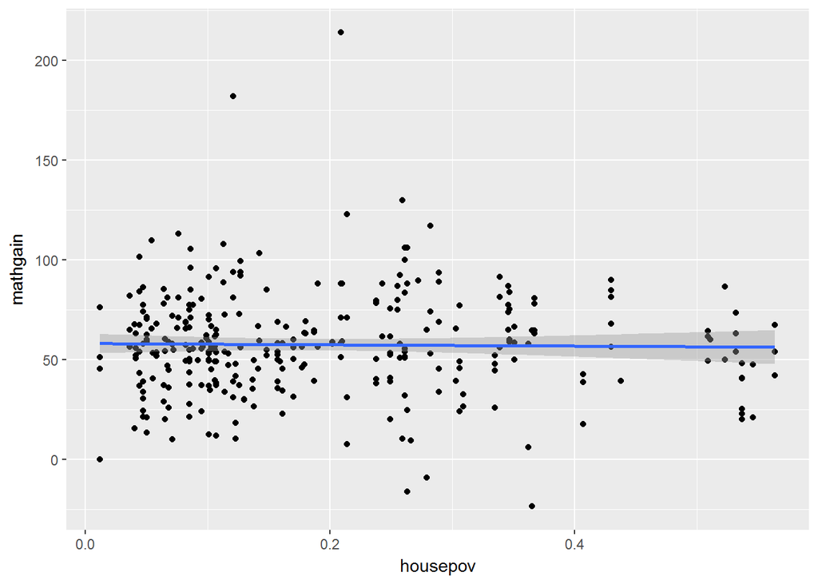

```r
# First, plot the hosepov and mathgain at the classroom-level from the classData data.frame
ggplot(data = classData, aes(x = housepov, y = mathgain)) +
    geom_point() +
    geom_smooth(method = 'lm')
```

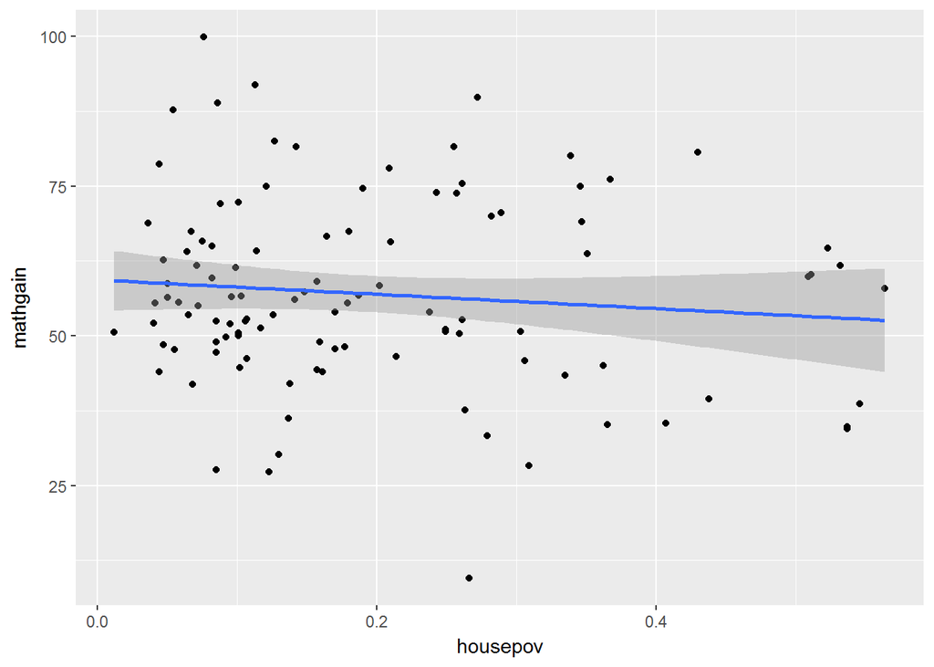

```r
# Second, plot the hosepov and mathgain at the school-level from the schoolData data.frame
ggplot(data = schoolData, aes(x = housepov, y = mathgain)) +
    geom_point() +
    geom_smooth(method = 'lm')
```

```r
# Third, compare your liner regression results from the previous expercise to the two new models
summary( lm(mathgain ~ housepov, data = studentData)) ## student-level data
```

```
##
## Call:
## lm(formula = mathgain ~ housepov, data = studentData)
##
## Residuals:
##      Min       1Q   Median       3Q      Max
## -168.226  -22.222   -1.306   19.763  195.156
##
## Coefficients:
##             Estimate Std. Error t value Pr(>|t|)
## (Intercept)   56.937      1.674   34.02   <2e-16 ***
## housepov       3.531      7.515    0.47    0.639
## ---
## Signif. codes:  0 '***' 0.001 '**' 0.01 '*' 0.05 '.' 0.1 ' ' 1
##
## Residual standard error: 34.63 on 1188 degrees of freedom
## Multiple R-squared:  0.0001858,  Adjusted R-squared:  -0.0006558
## F-statistic: 0.2208 on 1 and 1188 DF,  p-value: 0.6385
```

```r
summary( lm(mathgain ~ housepov, data = classData)) ## class-level data
```

```
##
## Call:
## lm(formula = mathgain ~ housepov, data = classData)
##
## Residuals:
##     Min      1Q  Median      3Q     Max
## -80.479 -14.444  -1.447  13.151 156.516
##
## Coefficients:
##             Estimate Std. Error t value Pr(>|t|)
## (Intercept)   58.160      2.542  22.879   <2e-16 ***
## housepov      -3.236     10.835  -0.299    0.765
## ---
## Signif. codes:  0 '***' 0.001 '**' 0.01 '*' 0.05 '.' 0.1 ' ' 1
##
## Residual standard error: 26.14 on 310 degrees of freedom
## Multiple R-squared:  0.0002876,  Adjusted R-squared:  -0.002937
## F-statistic: 0.08918 on 1 and 310 DF,  p-value: 0.7654
```

```r
summary( lm(mathgain ~ housepov, data = schoolData)) ## school-level data
```

```
##
## Call:
## lm(formula = mathgain ~ housepov, data = schoolData)
##
## Residuals:
##     Min      1Q  Median      3Q     Max
## -46.660  -9.947  -2.494   9.546  41.445
##
## Coefficients:
##             Estimate Std. Error t value Pr(>|t|)
## (Intercept)   59.338      2.624  22.616   <2e-16 ***
## housepov     -11.948     10.987  -1.087    0.279
## ---
## Signif. codes:  0 '***' 0.001 '**' 0.01 '*' 0.05 '.' 0.1 ' ' 1
##
## Residual standard error: 15.8 on 105 degrees of freedom
## Multiple R-squared:  0.01114,    Adjusted R-squared:  0.00172
## F-statistic: 1.183 on 1 and 105 DF,  p-value: 0.2793
```

```r
# Plot the means of your data, predictor is your x-variable, response is your y-variable, and intDemo is your data.frame
intDemo <- data.frame(predictor=factor(c(rep("a", 5), rep("b", 5), rep("c", 5))),
                      response=c(-1.207, 0.277, 1.084, -2.346, 0.429, 5.759, 4.138, 4.18, 4.153, 3.665, 9.046, 8.003, 8.447, 10.129, 11.919)
                      )
str(intDemo)
```

```
## 'data.frame':    15 obs. of  2 variables:
##  $ predictor: Factor w/ 3 levels "a","b","c": 1 1 1 1 1 2 2 2 2 2 ...
##  $ response : num  -1.207 0.277 1.084 -2.346 0.429 ...
```

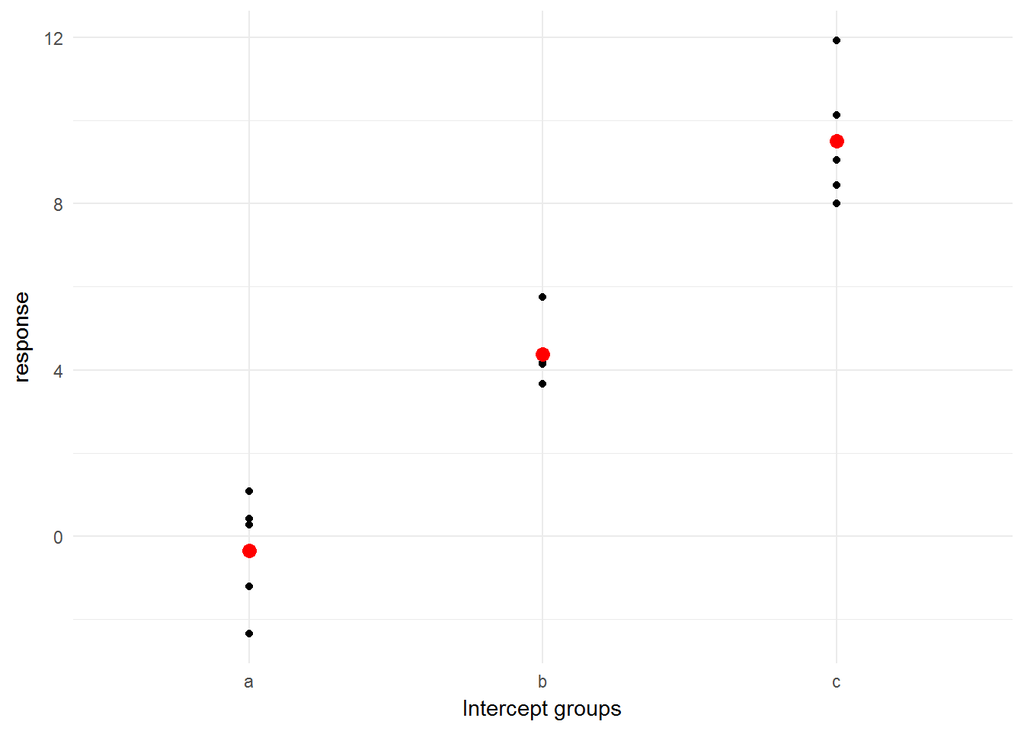

```r
ggIntDemo <- ggplot(intDemo, aes(x = predictor, y = response) ) +
    geom_point() +
    theme_minimal() + stat_summary(fun.y = "mean", color = "red",
                                   size = 3, geom = "point") +
    xlab("Intercept groups")
print(ggIntDemo)
```

```r
# Fit a linear model to your data where response is "predicted by"(~) predictor
intModel <- lm( response ~ predictor - 1 , data = intDemo)
summary(intModel)
```

```
##
## Call:
## lm(formula = response ~ predictor - 1, data = intDemo)
##
## Residuals:
##     Min      1Q  Median      3Q     Max
## -1.9934 -0.7842 -0.2260  0.7056  2.4102
##
## Coefficients:
##            Estimate Std. Error t value Pr(>|t|)
## predictora  -0.3526     0.5794  -0.609    0.554
## predictorb   4.3790     0.5794   7.558 6.69e-06 ***
## predictorc   9.5088     0.5794  16.412 1.38e-09 ***
## ---
## Signif. codes:  0 '***' 0.001 '**' 0.01 '*' 0.05 '.' 0.1 ' ' 1
##
## Residual standard error: 1.296 on 12 degrees of freedom
## Multiple R-squared:  0.9646, Adjusted R-squared:  0.9557
## F-statistic:   109 on 3 and 12 DF,  p-value: 5.696e-09
```

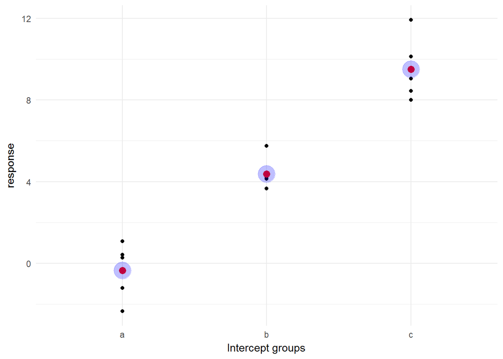

```r
extractAndPlotResults <- function(intModel){
    intCoefPlot <- broom::tidy(intModel)
    intCoefPlot$term <- factor(gsub("predictor", "", intCoefPlot$term))

    plotOut <- ggIntDemo + geom_point(data = intCoefPlot,
                           aes(x = term, y = estimate),
                           position = position_dodge(width = 0.4),
                           color = 'blue', size = 8, alpha = 0.25)
    print(plotOut)
}


# Run the next code that extracts out the model's coeffiecents and plots them
extractAndPlotResults(intModel)
```

```r
multIntDemo <- data.frame(group=factor(c(rep("a", 5), rep("b", 5), rep("c", 5))),
                          x=rep(0:4, times=3),
                          intercept=c(4.11, -1.69, 1.09, 1.9, 1.21, 4.63, 10.29, 4.67, 12.06, 4.78, 15.22, 19.15, 4.44, 8.88, 9.47),
                          response=c(4.11, 2.31, 9.09, 13.9, 17.21, 4.63, 14.29, 12.67, 24.06, 20.78, 15.22, 23.15, 12.44, 20.88, 25.47)
                          )
str(multIntDemo)
```

```
## 'data.frame':    15 obs. of  4 variables:
##  $ group    : Factor w/ 3 levels "a","b","c": 1 1 1 1 1 2 2 2 2 2 ...
##  $ x        : int  0 1 2 3 4 0 1 2 3 4 ...
##  $ intercept: num  4.11 -1.69 1.09 1.9 1.21 ...
##  $ response : num  4.11 2.31 9.09 13.9 17.21 ...
```

```r
plot_output1 <- function(out1){
    ggmultIntgDemo <- ggplot( multIntDemo, aes(x = x, y = response) ) +
        geom_point(aes(color = group)) +
        theme_minimal() +
        scale_color_manual(values = c("blue", "black", "red")) +
        stat_smooth(method = 'lm', fill = NA, color = 'orange', size = 3)
    print(ggmultIntgDemo)
}

plot_output2 <- function(out2){
    out2Tidy <- broom::tidy(out2)
    out2Tidy$term <- gsub("group", "", out2Tidy$term)
    out2Plot <- data.frame(group = out2Tidy[ -1, 1],
                           slope = out2Tidy[ 1, 2],
                           intercept = out2Tidy[ -1, 2])
    ggmultIntgDemo2 <- ggplot( multIntDemo, aes(x = x, y = response) ) +
        geom_point(aes(color = group))+
        theme_minimal() +
        scale_color_manual(values = c("blue", "black", "red")) +
        geom_abline(data = out2Plot,
                    aes(intercept = intercept, slope = slope, color = group))
    print(ggmultIntgDemo2)
}

plot_output3 <- function(out3){
    ggmultIntgDemo3 <- ggplot( multIntDemo, aes(x = x, y = response) ) +
        geom_point(aes(color = group)) +
        theme_minimal() +
        scale_color_manual(values = c("blue", "black", "red")) +
        stat_smooth(method = 'lm', aes(color = group), fill = NA)
    print(ggmultIntgDemo3)
}

# First, run a model without considering different intercept for each group
out1 <- lm( response ~ x, data=multIntDemo )
summary(out1)
```

```
##
## Call:
## lm(formula = response ~ x, data = multIntDemo)
##
## Residuals:
##    Min     1Q Median     3Q    Max
## -9.101 -4.021 -2.011  3.590 11.739
##
## Coefficients:
##             Estimate Std. Error t value Pr(>|t|)
## (Intercept)    8.141      2.615   3.113  0.00824 **
## x              3.270      1.068   3.062  0.00908 **
## ---
## Signif. codes:  0 '***' 0.001 '**' 0.01 '*' 0.05 '.' 0.1 ' ' 1
##
## Residual standard error: 5.848 on 13 degrees of freedom
## Multiple R-squared:  0.4191, Adjusted R-squared:  0.3744
## F-statistic: 9.378 on 1 and 13 DF,  p-value: 0.009081
```

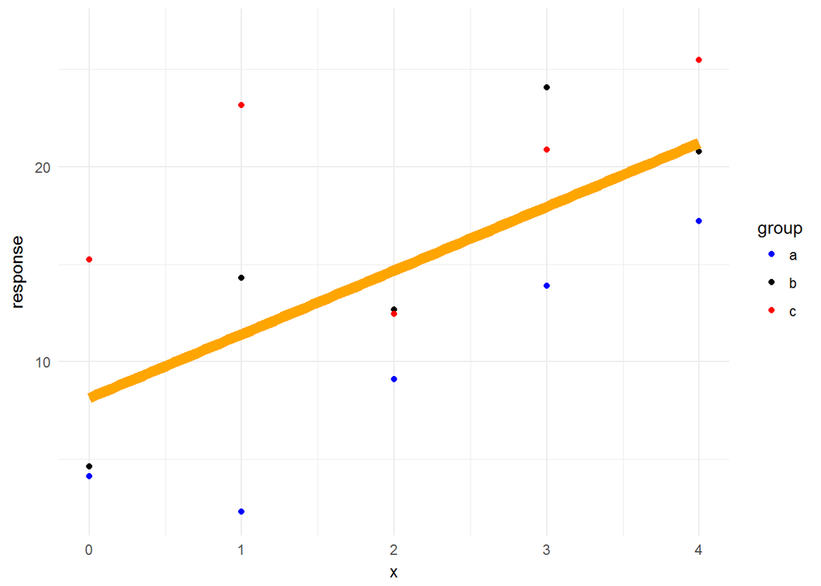

```r
plot_output1(out1)
```

```r
# Considering same slope but different intercepts
out2 <- lm( response ~ x + group - 1, data=multIntDemo )
summary(out2)
```

```
##
## Call:
## lm(formula = response ~ x + group - 1, data = multIntDemo)
##
## Residuals:
##    Min     1Q Median     3Q    Max
## -6.992 -2.219 -0.234  1.810  6.988
##
## Coefficients:
##        Estimate Std. Error t value Pr(>|t|)
## x        3.2697     0.7516   4.350 0.001155 **
## groupa   2.7847     2.3767   1.172 0.266085
## groupb   8.7467     2.3767   3.680 0.003625 **
## groupc  12.8927     2.3767   5.425 0.000209 ***
## ---
## Signif. codes:  0 '***' 0.001 '**' 0.01 '*' 0.05 '.' 0.1 ' ' 1
##
## Residual standard error: 4.117 on 11 degrees of freedom
## Multiple R-squared:  0.9534, Adjusted R-squared:  0.9364
## F-statistic: 56.23 on 4 and 11 DF,  p-value: 2.97e-07
```

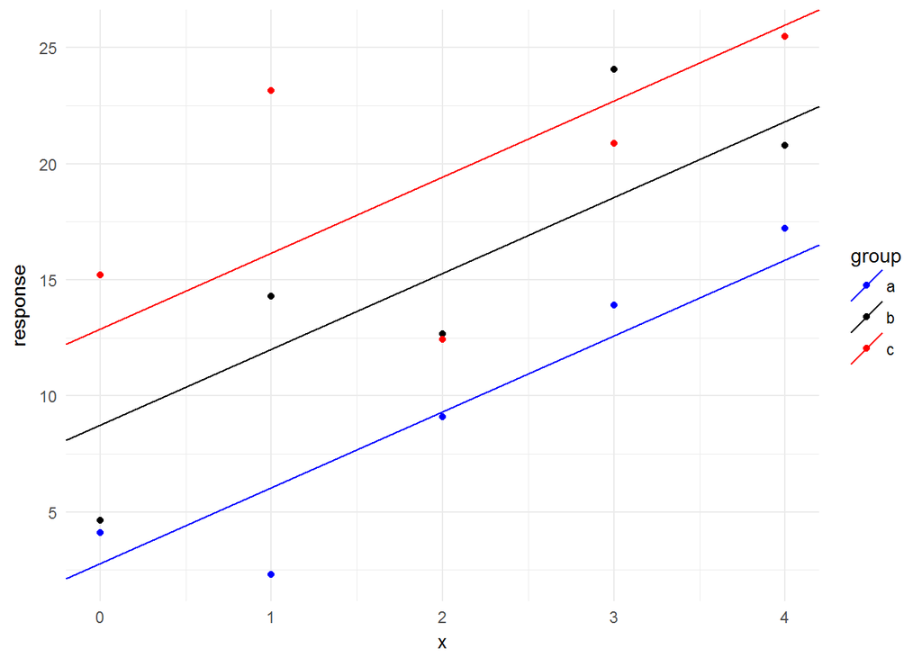

```r
plot_output2(out2)
```

```r
# Consdering different slope and intercept for each group (i.e., an interaction)
out3 <- lm( response ~ x + group - 1 + x:group, multIntDemo)
summary(out3)
```

```
##
## Call:
## lm(formula = response ~ x + group - 1 + x:group, data = multIntDemo)
##
## Residuals:
##    Min     1Q Median     3Q    Max
## -6.992 -2.429 -0.234  2.368  5.541
##
## Coefficients:
##          Estimate Std. Error t value Pr(>|t|)
## x           3.779      1.308   2.888 0.017941 *
## groupa      1.766      3.205   0.551 0.595053
## groupb      6.872      3.205   2.144 0.060621 .
## groupc     15.786      3.205   4.925 0.000819 ***
## x:groupb    0.428      1.851   0.231 0.822263
## x:groupc   -1.956      1.851  -1.057 0.318050
## ---
## Signif. codes:  0 '***' 0.001 '**' 0.01 '*' 0.05 '.' 0.1 ' ' 1
##
## Residual standard error: 4.138 on 9 degrees of freedom
## Multiple R-squared:  0.9615, Adjusted R-squared:  0.9358
## F-statistic: 37.42 on 6 and 9 DF,  p-value: 7.263e-06
```

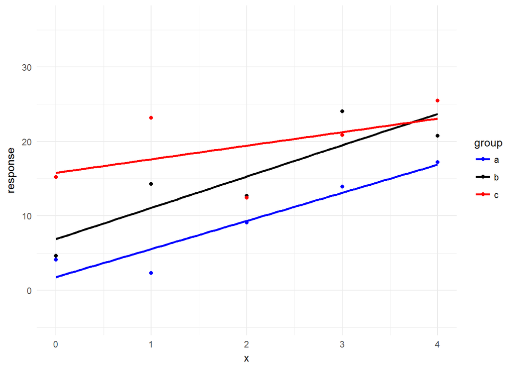

```r
plot_output3(out3)
```

```r
multIntDemo$intercept <- c(-0.87, 3.35, 1.25, 0.88, -1.05, 4.55, 1.22, 3.34, 1.26, 3.75, 7.71, 9.59, 2.28, 1.9, 13.35)
multIntDemo$response <- c(-0.87, 6.35, 7.25, 9.88, 10.95, 4.55, 4.22, 9.34, 10.26, 15.75, 7.71, 12.59, 8.28, 10.9, 25.35)

# Run model
outLmer <- lme4::lmer( response ~ x + ( 1 | group), multIntDemo)

# Look at model outputs
summary( outLmer )
```

```
## Linear mixed model fit by REML ['lmerMod']
## Formula: response ~ x + (1 | group)
##    Data: multIntDemo
##
## REML criterion at convergence: 76.9
##
## Scaled residuals:
##      Min       1Q   Median       3Q      Max
## -1.31582 -0.61105 -0.01593  0.45125  2.19118
##
## Random effects:
##  Groups   Name        Variance Std.Dev.
##  group    (Intercept)  7.98    2.825
##  Residual             10.71    3.272
## Number of obs: 15, groups:  group, 3
##
## Fixed effects:
##             Estimate Std. Error t value
## (Intercept)   3.5540     2.1913   1.622
## x             2.9733     0.5975   4.977
##
## Correlation of Fixed Effects:
##   (Intr)
## x -0.545
```

```r
broom::tidy( outLmer )
```

```
##                      term estimate std.error statistic    group
## 1             (Intercept) 3.554000 2.1912887  1.621877    fixed
## 2                       x 2.973333 0.5974739  4.976507    fixed
## 3    sd_(Intercept).group 2.824834        NA        NA    group
## 4 sd_Observation.Residual 3.272500        NA        NA Residual
```

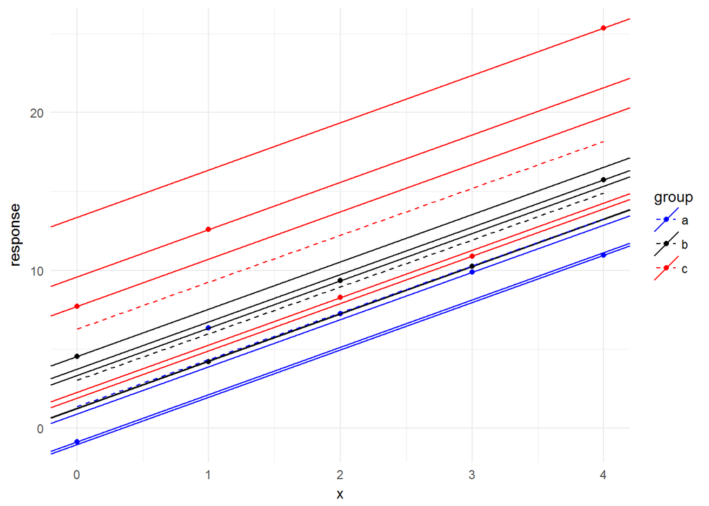

```r
extractAndPlotOutput <- function(outLmer, slope=3){
    multIntDemo$lmerPredict <- predict(outLmer)
    ggmultIntgDemo2 <- ggplot( multIntDemo, aes(x = x, y = response) ) +
        geom_point(aes(color = group))+
        theme_minimal() +
        scale_color_manual(values = c("blue", "black", "red")) +
        geom_abline(data = multIntDemo,
                    aes(intercept = intercept, slope = slope, color = group))
    outPlot <-  ggmultIntgDemo2 +
                geom_line( data =  multIntDemo,
                      aes(x = x, y = lmerPredict, color = group),
                      linetype = 2)
    print(outPlot)
}


# Extract predictor variables and plot
extractAndPlotOutput(outLmer)
```

```r
# Random effect slopes
multIntDemo$response <- c(-0.72, 1.5, 4.81, 6.61, 13.62, 10.21, 9.64, 11.91, 16.39, 16.97, 8.76, 14.79, 15.83, 15.27, 17.36)
multIntDemo$intercept <- c(-0.72, -1.5, -1.19, -2.39, 1.62, 10.21, 6.64, 5.91, 7.39, 4.97, 8.76, 11.79, 9.83, 6.27, 5.36)

outLmer2 <- lme4::lmer( response ~ ( x|group ), multIntDemo)
summary(outLmer2)
```

```
## Linear mixed model fit by REML ['lmerMod']
## Formula: response ~ (x | group)
##    Data: multIntDemo
##
## REML criterion at convergence: 69.7
##
## Scaled residuals:
##      Min       1Q   Median       3Q      Max
## -1.56747 -0.54105 -0.06286  0.75141  1.27947
##
## Random effects:
##  Groups   Name        Variance Std.Dev. Corr
##  group    (Intercept) 273.998  16.553
##           x             6.096   2.469   -1.00
##  Residual               2.466   1.570
## Number of obs: 15, groups:  group, 3
##
## Fixed effects:
##             Estimate Std. Error t value
## (Intercept)   21.676      1.383   15.67
```

```r
broom::tidy(outLmer2)
```

```
##                      term  estimate std.error statistic    group
## 1             (Intercept) 21.675699  1.383061  15.67226    fixed
## 2    sd_(Intercept).group 16.552871        NA        NA    group
## 3              sd_x.group  2.468959        NA        NA    group
## 4 cor_(Intercept).x.group -1.000000        NA        NA    group
## 5 sd_Observation.Residual  1.570349        NA        NA Residual
```

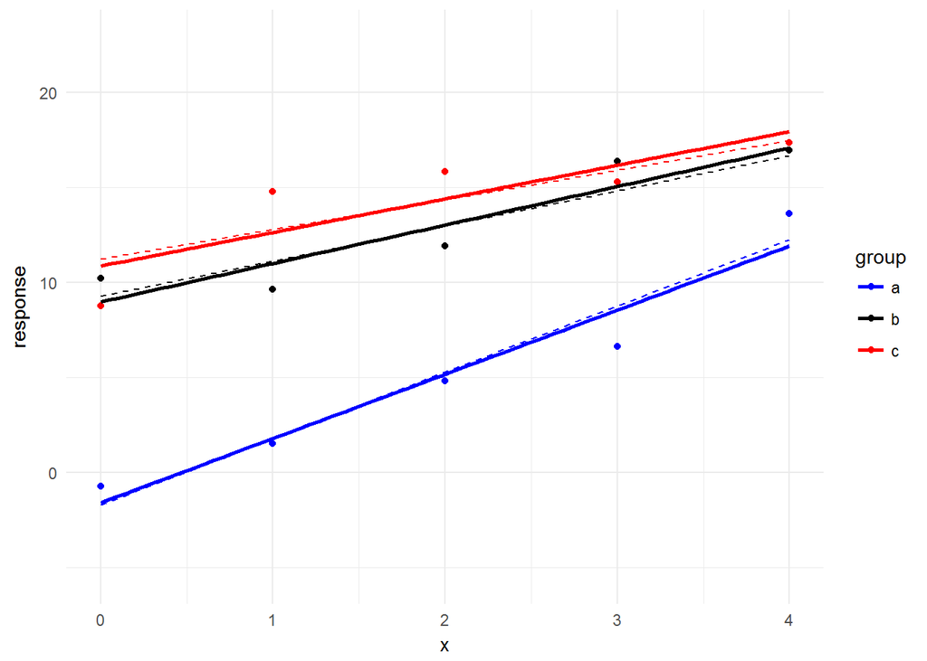

```r
plotOutput <- function(outLmer2){
    multIntDemo$lmerPredict2 <- predict(outLmer2)
    ggmultIntgDemo3 <- ggplot( multIntDemo, aes(x = x, y = response) ) +
        geom_point(aes(color = group)) +
        theme_minimal() +
        scale_color_manual(values = c("blue", "black", "red")) +
        stat_smooth(method = 'lm', aes(color = group), fill = NA)
    plotOut <- ggmultIntgDemo3 +
            geom_line( data =  multIntDemo,
                      aes(x = x, y = lmerPredict2, color = group),
                      linetype = 2)
    print(plotOut)
}


# Extract and plot
plotOutput(outLmer2)
```

```r
# Mixed effect model
lmerModel <- lme4::lmer(mathgain ~ sex +
                  mathprep + mathknow + (1|classid) +
                  (1|schoolid), data = studentData, na.action = "na.omit",
                  REML = TRUE)
summary(lmerModel)
```

```
## Linear mixed model fit by REML ['lmerMod']
## Formula:
## mathgain ~ sex + mathprep + mathknow + (1 | classid) + (1 | schoolid)
##    Data: studentData
##
## REML criterion at convergence: 10677.9
##
## Scaled residuals:
##     Min      1Q  Median      3Q     Max
## -4.3203 -0.6146 -0.0294  0.5467  5.5331
##
## Random effects:
##  Groups   Name        Variance Std.Dev.
##  classid  (Intercept)  103.57  10.177
##  schoolid (Intercept)   85.44   9.244
##  Residual             1019.47  31.929
## Number of obs: 1081, groups:  classid, 285; schoolid, 105
##
## Fixed effects:
##             Estimate Std. Error t value
## (Intercept)   52.250      3.838  13.613
## sexfemale     -1.526      2.041  -0.747
## mathprep       2.426      1.298   1.869
## mathknow       2.405      1.299   1.851
##
## Correlation of Fixed Effects:
##           (Intr) sexfml mthprp
## sexfemale -0.268
## mathprep  -0.878  0.001
## mathknow  -0.003  0.011  0.005
```

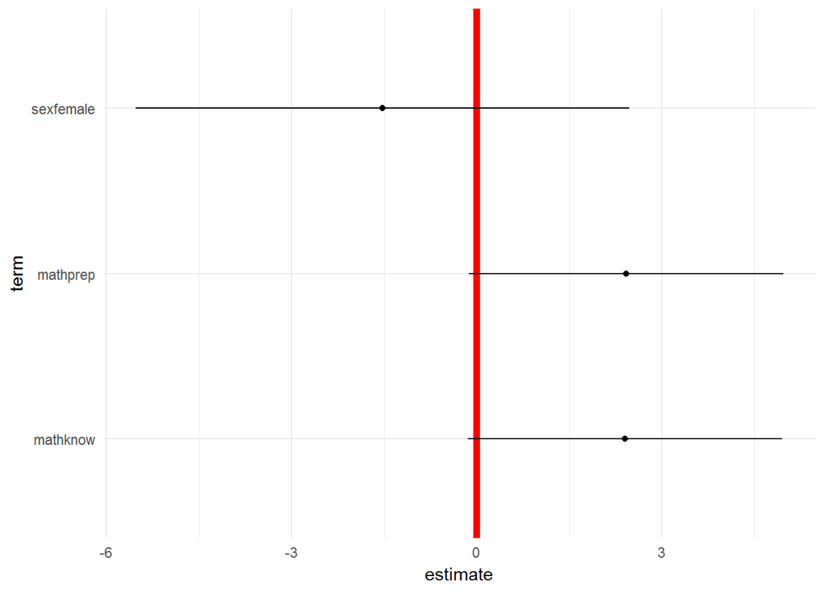

```r
extractAndPlot <- function(lmerModel){
    modelOutPlot <- broom::tidy(lmerModel, conf.int = TRUE)
    modelOutPlot <- modelOutPlot[ modelOutPlot$group =="fixed" &
                               modelOutPlot$term != "(Intercept)", ]
    plotOut <- ggplot(modelOutPlot, aes(x = term, y = estimate,
                             ymin = conf.low,
                             ymax = conf.high)) +
            theme_minimal() +
            geom_hline(yintercept = 0.0, color = 'red', size = 2.0) +
            geom_point() +
            geom_linerange() + coord_flip()
    print(plotOut)
}


# Extract and plot
extractAndPlot(lmerModel)
```

Chapter 2 - Linear Mixed-Effect Models

Linear mixed effect model - Birth rates data:

- Small populations are highly sensitive to stochastic effects - if the mean is 1, a group of 5 might have 0 or 10
- Questions about how counties may impact birth rates, over and above other demographic factors
  - Example of plotting birth rate vs. county - will see both the highest and lowest birth rates in the smallest counties
- Random effect syntax for the lmer model includes
  - (1 | group) - random intercept with fixed mean
  - (1 | g1/g2) - intercepts vary among g1 and g2 within g2
  - (1 | g1) + (1 | g2) - random intercepts for two variables
  - x + (x | g) - correlated random slope and intercept
  - x + (x || g) - uncorrelated random slope and intercept
  - See lme4 documentation for additional details

Understanding and reporting the outputs of lmer:

- The output from lmer is similar to the output from lm, but with some key differences - if using print(), will see
  - The method used is REML - restricted maximum likelihood - which tends to solve better than maximum likelihood for these problems
  - There is an REML convergence criteria, which can be a helpful diagnostic
  - Can see the standard deviations for both the state and the residual, along with the number of observations
  - Get the fixed effects coefficients in a similar form as lm()
- The summary() call on lmer produces several additional outputs
  - Residuals summary
  - Fixed effects estimates include SE and t-values (but not p-values)
  - Correlations of fixed effects
- Can grab only the fixed effects using fixef(myLMERObject)
  - Can grab only the random effects using ranef(myLMERObject), though these will not have confidence intervals
  - The random effects confidence intervals could be estimated using bootstrapping or Bayesian methods per the author of lme4 - but actual random effects are just unobserved random variables rather than parameters
- Can grab only the confidence intervals using confint(myLMERObject)
- Need to be careful in reporting the results - figures vs. tables vs. in-line descriptions

Statistical inference with Maryland crime data:

- The Maryland crime data is available on data.gov - interesting for many public and private purposes
- The null hypothsis test can be used with LMER - frequentist approach
  - By default, lmer does not provide p-values, as there is ongoing debate as to the degrees of freedom and impact on reported results
  - Can use lmerTest package to calculate and report on the p-values
- Can use ANOVA to look at the variability explained by one model versus another model, and the associated degrees of freedom needed

Example code includes:

```r
# Read in births data
rawBirths <- read.csv("./RInputFiles/countyBirthsDataUse.csv")
countyBirthsData <- rawBirths
str(countyBirthsData)
```

```
## 'data.frame':    580 obs. of  8 variables:
##  $ X                 : int  1 2 3 4 5 6 7 8 9 10 ...
##  $ Year              : int  2015 2015 2015 2015 2015 2015 2015 2015 2015 2015 ...
##  $ TotalPopulation   : int  203709 115620 103057 104173 660367 156993 353089 415395 226519 119565 ...
##  $ BirthRate         : num  11.5 12.1 11.8 12.4 13.3 ...
##  $ AverageBirthWeight: num  3261 3209 3239 3207 3177 ...
##  $ AverageAgeofMother: num  27.5 26.3 25.8 26.9 27.9 ...
##  $ CountyName        : Factor w/ 472 levels "Ada","Adams",..: 22 64 141 189 200 229 248 273 278 279 ...
##  $ State             : Factor w/ 50 levels "AK","AL","AR",..: 2 2 2 2 2 2 2 2 2 2 ...
```

```r
# First, build a lmer with state as a random effect. Then look at the model's summary and the plot of residuals.
birthRateStateModel <- lme4::lmer(BirthRate ~ (1|State), data=countyBirthsData)
summary(birthRateStateModel)
```

```
## Linear mixed model fit by REML ['lmerMod']
## Formula: BirthRate ~ (1 | State)
##    Data: countyBirthsData
##
## REML criterion at convergence: 2411
##
## Scaled residuals:
##     Min      1Q  Median      3Q     Max
## -2.7957 -0.6056 -0.1063  0.5211  5.5948
##
## Random effects:
##  Groups   Name        Variance Std.Dev.
##  State    (Intercept) 1.899    1.378
##  Residual             3.256    1.804
## Number of obs: 578, groups:  State, 50
##
## Fixed effects:
##             Estimate Std. Error t value
## (Intercept)  12.3362     0.2216   55.67
```

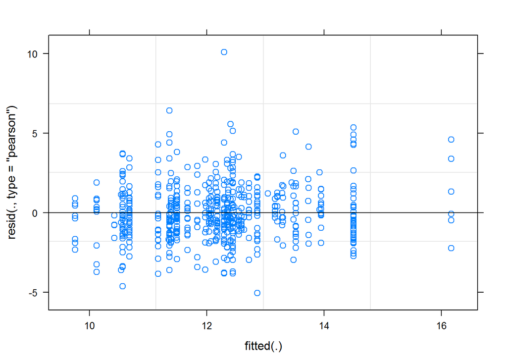

```r
plot(birthRateStateModel)
```

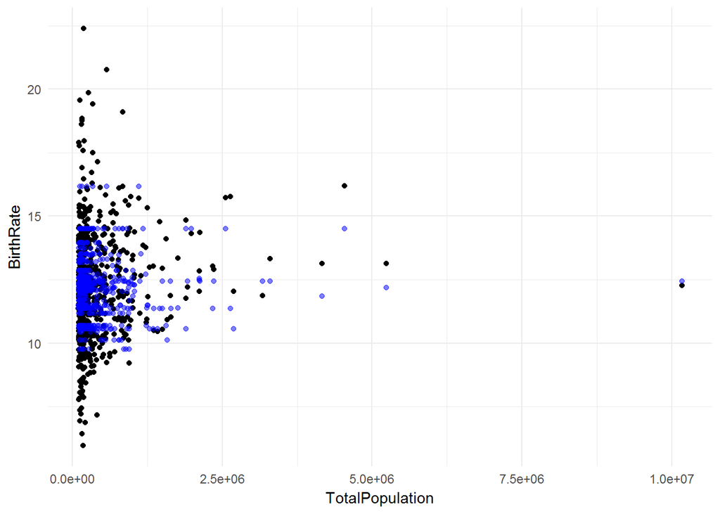

```r
# Next, plot the predicted values from the model ontop of the plot shown during the video.
countyBirthsData$birthPredictState <- predict(birthRateStateModel, countyBirthsData)
ggplot() + theme_minimal() +
    geom_point(data =countyBirthsData, aes(x = TotalPopulation, y = BirthRate)) +
    geom_point(data = countyBirthsData, aes(x = TotalPopulation, y = birthPredictState),
               color = 'blue', alpha = 0.5
               )
```

```r
# Include the AverageAgeofMother as a fixed effect within the lmer and state as a random effect
ageMotherModel <- lme4::lmer( BirthRate ~ AverageAgeofMother + (1|State), data=countyBirthsData)
summary(ageMotherModel)
```

```
## Linear mixed model fit by REML ['lmerMod']
## Formula: BirthRate ~ AverageAgeofMother + (1 | State)
##    Data: countyBirthsData
##
## REML criterion at convergence: 2347.6
##
## Scaled residuals:
##     Min      1Q  Median      3Q     Max
## -2.9602 -0.6086 -0.1042  0.5144  5.2686
##
## Random effects:
##  Groups   Name        Variance Std.Dev.
##  State    (Intercept) 1.562    1.250
##  Residual             2.920    1.709
## Number of obs: 578, groups:  State, 50
##
## Fixed effects:
##                    Estimate Std. Error t value
## (Intercept)        27.57033    1.81801  15.165
## AverageAgeofMother -0.53549    0.06349  -8.434
##
## Correlation of Fixed Effects:
##             (Intr)
## AvrgAgfMthr -0.994
```

```r
# Compare the random-effect model to the linear effect model
summary(lm(BirthRate ~ AverageAgeofMother, data = countyBirthsData))
```

```
##
## Call:
## lm(formula = BirthRate ~ AverageAgeofMother, data = countyBirthsData)
##
## Residuals:
##     Min      1Q  Median      3Q     Max
## -6.8304 -1.3126 -0.1795  1.2198  8.7327
##
## Coefficients:
##                    Estimate Std. Error t value Pr(>|t|)
## (Intercept)        29.06637    1.83374  15.851   <2e-16 ***
## AverageAgeofMother -0.59380    0.06441  -9.219   <2e-16 ***
## ---
## Signif. codes:  0 '***' 0.001 '**' 0.01 '*' 0.05 '.' 0.1 ' ' 1
##
## Residual standard error: 2.065 on 576 degrees of freedom
##   (2 observations deleted due to missingness)
## Multiple R-squared:  0.1286, Adjusted R-squared:  0.1271
## F-statistic: 84.99 on 1 and 576 DF,  p-value: < 2.2e-16
```

```r
# Include the AverageAgeofMother as a correlated random-effect slope parameter
ageMotherModelRandomCorrelated <- lme4::lmer(BirthRate ~ AverageAgeofMother + (AverageAgeofMother|State),
                       countyBirthsData)
summary(ageMotherModelRandomCorrelated)
```

```
## Linear mixed model fit by REML ['lmerMod']
## Formula: BirthRate ~ AverageAgeofMother + (AverageAgeofMother | State)
##    Data: countyBirthsData
##
## REML criterion at convergence: 2337.5
##
## Scaled residuals:
##     Min      1Q  Median      3Q     Max
## -2.8399 -0.5966 -0.1133  0.5228  5.1815
##
## Random effects:
##  Groups   Name               Variance Std.Dev. Corr
##  State    (Intercept)        78.75816 8.8746
##           AverageAgeofMother  0.08482 0.2912   -0.99
##  Residual                     2.80306 1.6742
## Number of obs: 578, groups:  State, 50
##
## Fixed effects:
##                    Estimate Std. Error t value
## (Intercept)        27.22042    2.41281  11.282
## AverageAgeofMother -0.52347    0.08302  -6.306
##
## Correlation of Fixed Effects:
##             (Intr)
## AvrgAgfMthr -0.997
```

```r
# Include the AverageAgeofMother as a correlated random-effect slope parameter
ageMotherModelRandomUncorrelated <- lme4::lmer(BirthRate ~ AverageAgeofMother +
                                                    (AverageAgeofMother || State), data=countyBirthsData
                                               )
summary(ageMotherModelRandomUncorrelated)
```

```
## Linear mixed model fit by REML ['lmerMod']
## Formula:
## BirthRate ~ AverageAgeofMother + ((1 | State) + (0 + AverageAgeofMother |
##     State))
##    Data: countyBirthsData
##
## REML criterion at convergence: 2347.6
##
## Scaled residuals:
##     Min      1Q  Median      3Q     Max
## -2.9602 -0.6086 -0.1042  0.5144  5.2686
##
## Random effects:
##  Groups   Name               Variance Std.Dev.
##  State    (Intercept)        1.562    1.250
##  State.1  AverageAgeofMother 0.000    0.000
##  Residual                    2.920    1.709
## Number of obs: 578, groups:  State, 50
##
## Fixed effects:
##                    Estimate Std. Error t value
## (Intercept)        27.57033    1.81801  15.165
## AverageAgeofMother -0.53549    0.06349  -8.434
##
## Correlation of Fixed Effects:
##             (Intr)
## AvrgAgfMthr -0.994
```

```r
out <- ageMotherModelRandomUncorrelated

# Extract the fixed-effect coefficients
lme4::fixef(out)
```

```
##        (Intercept) AverageAgeofMother
##         27.5703303         -0.5354886
```

```r
# Extract the random-effect coefficients
lme4::ranef(out)
```

```
## $State
##    (Intercept) AverageAgeofMother
## AK  1.03549149                  0
## AL -0.52500819                  0
## AR  0.48023356                  0
## AZ -1.04094123                  0
## CA  0.50530542                  0
## CO  0.09585582                  0
## CT -1.91638101                  0
## DC  0.96029532                  0
## DE -0.38938118                  0
## FL -1.87440508                  0
## GA  0.39776424                  0
## HI  0.08513474                  0
## IA  0.96279528                  0
## ID  1.17377458                  0
## IL -0.12739337                  0
## IN -0.32655206                  0
## KS  0.85650338                  0
## KY  0.64871300                  0
## LA  1.04437463                  0
## MA -1.40082047                  0
## MD  0.10842918                  0
## ME -1.63520397                  0
## MI -1.13797832                  0
## MN  0.93266233                  0
## MO  0.07081901                  0
## MS -0.21397453                  0
## MT -0.13190265                  0
## NC -0.28681241                  0
## ND  0.99847758                  0
## NE  1.49390428                  0
## NH -1.45440958                  0
## NJ -0.30089452                  0
## NM -0.69753301                  0
## NV  0.09012925                  0
## NY -0.58163335                  0
## OH -1.07390325                  0
## OK  0.77997159                  0
## OR -0.75845586                  0
## PA -1.59332743                  0
## RI -1.36395356                  0
## SC -0.59295090                  0
## SD  1.35141914                  0
## TN -0.13512968                  0
## TX  1.70872465                  0
## UT  3.66056804                  0
## VA  1.59187553                  0
## VT -0.51105276                  0
## WA  0.23008359                  0
## WI -0.51646717                  0
## WV -0.67684007                  0
```

```r
# Estimate the confidence intervals
(ciOut <- confint(out))
```

```
## Computing profile confidence intervals ...
```

```
##                         2.5 %      97.5 %
## .sig01              0.0000000  1.61243911
## .sig02              0.0000000  0.05033967
## .sigma              1.6091449  1.81592859
## (Intercept)        24.0121848 31.14668434
## AverageAgeofMother -0.6605319 -0.41123099
```

```r
# Technical note: Extracting out the regression coefficients from lmer is tricky (see discussion between the lmer and broom authors development)
# Extract out the parameter estimates and confidence intervals and manipulate the data
dataPlot <- data.frame(cbind( lme4::fixef(out), ciOut[ 4:5, ]))
rownames(dataPlot)[1] <- "Intercept"
colnames(dataPlot) <- c("mean", "l95", "u95")
dataPlot$parameter <- rownames(dataPlot)

# Print the new dataframe
print(dataPlot)
```

```
##                          mean        l95       u95          parameter
## Intercept          27.5703303 24.0121848 31.146684          Intercept
## AverageAgeofMother -0.5354886 -0.6605319 -0.411231 AverageAgeofMother
```

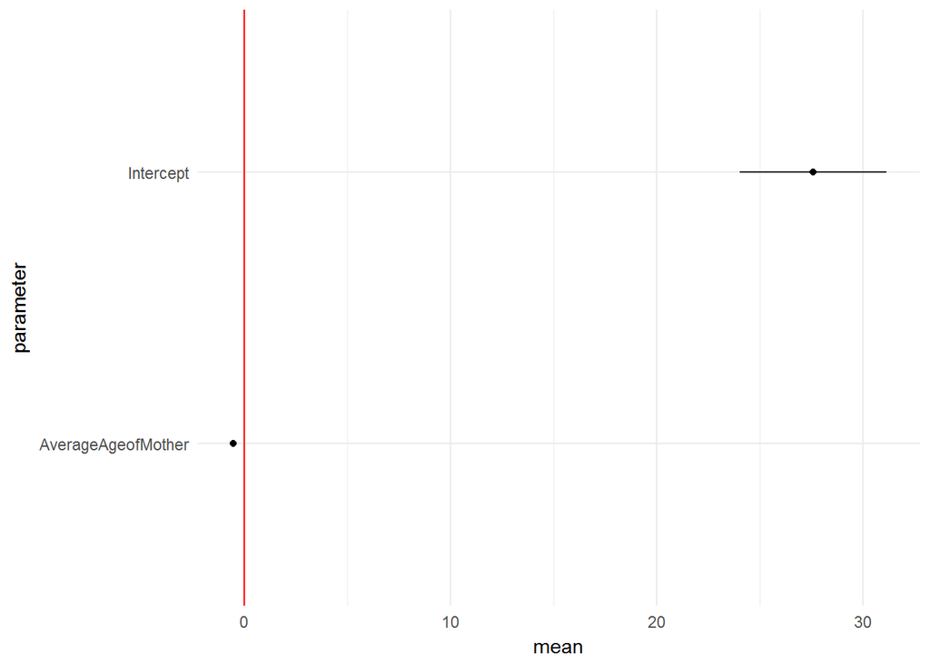

```r
# Plot the results using ggplot2
ggplot(dataPlot, aes(x = parameter, y = mean,
                     ymin = l95, ymax = u95)) +
    geom_hline( yintercept = 0, color = 'red' ) +
    geom_linerange() + geom_point() + coord_flip() + theme_minimal()
```

```r
# Read in crime data
rawCrime <- read.csv("./RInputFiles/MDCrime.csv")
MDCrime <- rawCrime
str(MDCrime)
```

```
## 'data.frame':    192 obs. of  5 variables:
##  $ X     : int  1 2 3 4 5 6 7 8 9 10 ...
##  $ County: Factor w/ 24 levels "ALLEGANY","ANNE ARUNDEL",..: 2 3 4 5 6 7 8 9 10 11 ...
##  $ Year  : int  2006 2006 2006 2006 2006 2006 2006 2006 2006 2006 ...
##  $ Crime : int  3167 10871 5713 257 149 374 490 729 181 752 ...
##  $ Year2 : int  0 0 0 0 0 0 0 0 0 0 ...
```

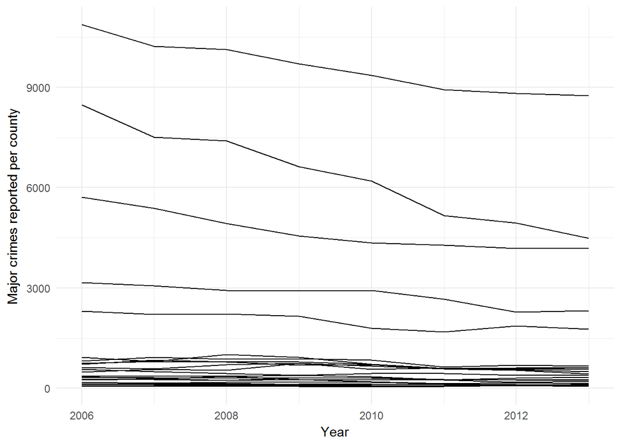

```r
plot1 <- ggplot(data = MDCrime, aes(x = Year, y = Crime, group = County)) +
    geom_line() + theme_minimal() +
    ylab("Major crimes reported per county")
print(plot1)
```

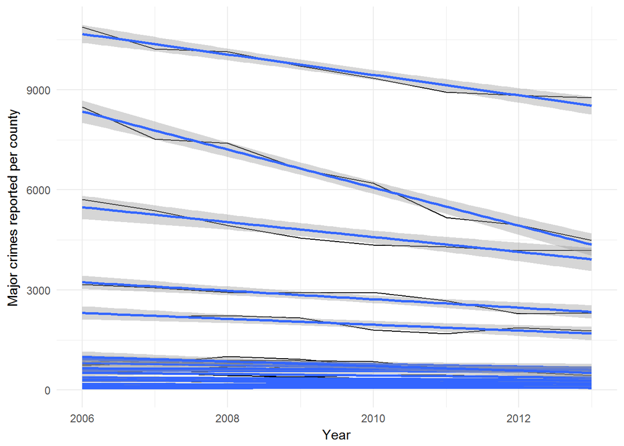

```r
plot1 + geom_smooth(method = 'lm')
```

```r
# Null hypothesis testing uses p-values to see if a variable is "significant"
# Recently, the abuse and overuse of null hypothesis testing and p-values has caused the American Statistical Association to issue a statement about the use of p-values
# Because of these criticisms and other numerical challenges, Doug Bates (the creator of the lme4 package) does not include p-values as part of his package
# However, you may still want to estimate p-values, because p-values are sill commonly used. Several packages exist, including the lmerTest package
# https://www.amstat.org/asa/files/pdfs/P-ValueStatement.pdf

# Load lmerTest
# library(lmerTest)

# Fit the model with Year as both a fixed and random-effect
lme4::lmer(Crime ~ Year + (1 + Year | County) , data = MDCrime)
```

```
## Linear mixed model fit by REML ['lmerMod']
## Formula: Crime ~ Year + (1 + Year | County)
##    Data: MDCrime
## REML criterion at convergence: 2891.03
## Random effects:
##  Groups   Name        Std.Dev. Corr
##  County   (Intercept) 655.2118
##           Year          0.8322 1.00
##  Residual             328.2865
## Number of obs: 192, groups:  County, 24
## Fixed Effects:
## (Intercept)         Year
##   136642.97       -67.33
## convergence code 0; 3 optimizer warnings; 0 lme4 warnings
```

```r
# Fit the model with Year2 rather than Year
out <- lme4::lmer(Crime ~ Year2 + (1 + Year2 | County) , data = MDCrime)

# Examine the model's output
summary(out)
```

```
## Linear mixed model fit by REML ['lmerMod']
## Formula: Crime ~ Year2 + (1 + Year2 | County)
##    Data: MDCrime
##
## REML criterion at convergence: 2535.7
##
## Scaled residuals:
##     Min      1Q  Median      3Q     Max
## -3.8081 -0.2235 -0.0390  0.2837  3.0768
##
## Random effects:
##  Groups   Name        Variance Std.Dev. Corr
##  County   (Intercept) 7587959  2754.63
##           Year2         16945   130.17  -0.91
##  Residual                8425    91.79
## Number of obs: 192, groups:  County, 24
##
## Fixed effects:
##             Estimate Std. Error t value
## (Intercept)  1577.28     562.42   2.804
## Year2         -67.33      26.73  -2.519
##
## Correlation of Fixed Effects:
##       (Intr)
## Year2 -0.907
```

```r
## Build the Null model with only County as a random-effect
null_model <- lme4::lmer(Crime ~ (1 | County) , data = MDCrime)

## Build the Year2 model with Year2 as a fixed and random slope and County as the random-effect
year_model <- lme4::lmer(Crime ~ Year2 + (1 + Year2 | County) , data = MDCrime)

## Compare the two models using an anova
anova(null_model, year_model)
```

```
## refitting model(s) with ML (instead of REML)
```

```
## Data: MDCrime
## Models:
## null_model: Crime ~ (1 | County)
## year_model: Crime ~ Year2 + (1 + Year2 | County)
##            Df    AIC    BIC  logLik deviance  Chisq Chi Df Pr(>Chisq)
## null_model  3 2954.4 2964.2 -1474.2   2948.4
## year_model  6 2568.9 2588.4 -1278.4   2556.9 391.52      3  < 2.2e-16 ***
## ---
## Signif. codes:  0 '***' 0.001 '**' 0.01 '*' 0.05 '.' 0.1 ' ' 1
```

Chapter 3 - Generalized Linear Mixed-Effect Models

Crash course on GLMs - relaxing the assumptions around normality of the residuals:

- Non-normal data can be transformed using arcsin or the like
- However, with advances in methodology, it is possible to more directly model the data using binomial and poisson distributions
- The basic glm call is glm(y ~ x, family=“”) # default is family=“gaussian”, which same as the lm()
- The Poisson distribution is frequently best for count data, such as website visitors per hour - mean equals variance (generally best for small counts less than 30; can use normals for large counts)
- For logistic regression, data can be entered in any of three formats
  - Binary (y=0 or 1) - glm(y ~ x, family=“binomial”)
  - Wilkinson-Rogers - glm(cbind(success, failure) ~ x, family=“binomial”)
  - Weighted - glm(y ~ x, weights=weights, family=“binomial”)
  - These methods differ primarily in the degrees of freedom (and thus deviance)

Binomial data - modeling data with only two outcomes:

- Traditional method for analysis includes looking at proportion of successes
- The GLM allows for direct looks at the data - logistic regression (logit)
- Binomial data can be fit using glmer(y ~ x + (1/group), family=“error term”)
- The regression coefficients can be difficult to explain, sometimes leading to the use of odds ratios instead
  - The odds ratio of 2.0 would mean 2:1 odds for that specific group

Count data:

- Examples like number of events per hour (website hits) or counts per area (birds)
- The count data differs from the binomial in that there is no pre-specified upper boundary
- While Chi-squared is often used for goodness of fit or test of association for count data, the Poisson GLM can be a nice alternative
  - glm(y ~ x, family=“poisson”)
  - glmer(y ~ x + (1|group), family=“poisson”)

Example code includes:

```r
# In this case study, we will be working with simulated dose-response data
# The response is mortality (1) or survival (0) at the end of a study. During this exercise, we will fit a logistic regression using all three methods described in the video
# You have been given two datasets. dfLong has the data in a "long" format with each row corresponding to an observation (i.e., a 0 or 1)
# dfShort has the data in an aggregated format with each row corresponding to a treatment (e.g., 6 successes, 4 failures, number of replicates = 10, proportion = 0.6)

dfLong <- data.frame(dose=c(0, 0, 0, 0, 0, 0, 0, 0, 0, 0, 0, 0, 0, 0, 0, 0, 0, 0, 0, 0, 2, 2, 2, 2, 2, 2, 2, 2, 2, 2, 2, 2, 2, 2, 2, 2, 2, 2, 2, 2, 4, 4, 4, 4, 4, 4, 4, 4, 4, 4, 4, 4, 4, 4, 4, 4, 4, 4, 4, 4, 6, 6, 6, 6, 6, 6, 6, 6, 6, 6, 6, 6, 6, 6, 6, 6, 6, 6, 6, 6, 8, 8, 8, 8, 8, 8, 8, 8, 8, 8, 8, 8, 8, 8, 8, 8, 8, 8, 8, 8, 10, 10, 10, 10, 10, 10, 10, 10, 10, 10, 10, 10, 10, 10, 10, 10, 10, 10, 10, 10),
                     mortality=c(0, 0, 0, 0, 0, 0, 0, 0, 0, 0, 0, 0, 0, 0, 0, 0, 0, 0, 0, 0, 0, 1, 0, 1, 0, 0, 1, 0, 0, 0, 0, 1, 0, 0, 0, 0, 0, 0, 0, 0, 1, 0, 0, 1, 1, 1, 0, 0, 0, 0, 0, 0, 0, 1, 1, 0, 0, 1, 0, 1, 0, 0, 1, 0, 1, 1, 0, 1, 1, 0, 1, 0, 1, 1, 0, 0, 0, 1, 1, 0, 0, 1, 1, 1, 0, 0, 1, 0, 0, 1, 0, 1, 0, 1, 0, 1, 1, 1, 1, 0, 1, 1, 1, 1, 1, 1, 1, 0, 0, 0, 1, 0, 1, 0, 1, 1, 0, 0, 1, 1)
                     )
str(dfLong)
```

```
## 'data.frame':    120 obs. of  2 variables:
##  $ dose     : num  0 0 0 0 0 0 0 0 0 0 ...
##  $ mortality: num  0 0 0 0 0 0 0 0 0 0 ...
```

```r
dfShort <- dfLong %>%
    group_by(dose) %>%
    summarize(mortality=sum(mortality), nReps=n()) %>%
    mutate(survival=nReps-mortality, mortalityP=mortality/nReps)
dfShort
```

```
## # A tibble: 6 x 5
##    dose mortality nReps survival mortalityP
##   <dbl>     <dbl> <int>    <dbl>      <dbl>
## 1  0         0       20    20.0       0
## 2  2.00      4.00    20    16.0       0.200
## 3  4.00      8.00    20    12.0       0.400
## 4  6.00     10.0     20    10.0       0.500
## 5  8.00     11.0     20     9.00      0.550
## 6 10.0      13.0     20     7.00      0.650
```

```r
# Fit a glm using data in a long format
fitLong <- glm(mortality ~ dose, data = dfLong, family = "binomial")
summary(fitLong)
```

```
##
## Call:
## glm(formula = mortality ~ dose, family = "binomial", data = dfLong)
##
## Deviance Residuals:
##     Min       1Q   Median       3Q      Max
## -1.5916  -0.8245  -0.4737   1.0440   1.8524
##
## Coefficients:
##             Estimate Std. Error z value Pr(>|z|)
## (Intercept) -2.13075    0.44532  -4.785 1.71e-06 ***
## dose         0.30663    0.06821   4.495 6.95e-06 ***
## ---
## Signif. codes:  0 '***' 0.001 '**' 0.01 '*' 0.05 '.' 0.1 ' ' 1
##
## (Dispersion parameter for binomial family taken to be 1)
##
##     Null deviance: 159.76  on 119  degrees of freedom
## Residual deviance: 134.71  on 118  degrees of freedom
## AIC: 138.71
##
## Number of Fisher Scoring iterations: 3
```

```r
# Fit a glm using data in a short format with two columns
fitShort <- glm( cbind(mortality , survival ) ~ dose , data = dfShort, family = "binomial")
summary(fitShort)
```

```
##
## Call:
## glm(formula = cbind(mortality, survival) ~ dose, family = "binomial",
##     data = dfShort)
##
## Deviance Residuals:
##       1        2        3        4        5        6
## -2.1186   0.2316   1.0698   0.6495  -0.2699  -0.6634
##
## Coefficients:
##             Estimate Std. Error z value Pr(>|z|)
## (Intercept) -2.13075    0.44537  -4.784 1.72e-06 ***
## dose         0.30663    0.06822   4.495 6.97e-06 ***
## ---
## Signif. codes:  0 '***' 0.001 '**' 0.01 '*' 0.05 '.' 0.1 ' ' 1
##
## (Dispersion parameter for binomial family taken to be 1)
##
##     Null deviance: 31.6755  on 5  degrees of freedom
## Residual deviance:  6.6214  on 4  degrees of freedom
## AIC: 27.415
##
## Number of Fisher Scoring iterations: 4
```

```r
# Fit a glm using data in a short format with weights
fitShortP <- glm( mortalityP ~ dose , data = dfShort, weights = nReps , family = "binomial")
summary(fitShortP)
```

```
##
## Call:
## glm(formula = mortalityP ~ dose, family = "binomial", data = dfShort,
##     weights = nReps)
##
## Deviance Residuals:
##       1        2        3        4        5        6
## -2.1186   0.2316   1.0698   0.6495  -0.2699  -0.6634
##
## Coefficients:
##             Estimate Std. Error z value Pr(>|z|)
## (Intercept) -2.13075    0.44537  -4.784 1.72e-06 ***
## dose         0.30663    0.06822   4.495 6.97e-06 ***
## ---
## Signif. codes:  0 '***' 0.001 '**' 0.01 '*' 0.05 '.' 0.1 ' ' 1
##
## (Dispersion parameter for binomial family taken to be 1)
##
##     Null deviance: 31.6755  on 5  degrees of freedom
## Residual deviance:  6.6214  on 4  degrees of freedom
## AIC: 27.415
##
## Number of Fisher Scoring iterations: 4
```

```r
y <- c(0, 1, 0, 1, 0, 1, 0, 1, 0, 2, 1, 2, 0, 1, 1, 0, 1, 5, 1, 1)
x <- c(1, 2, 3, 4, 5, 6, 7, 8, 9, 10, 11, 12, 13, 14, 15, 16, 17, 18, 19, 20)


# Fit the linear model
summary(lm(y ~ x))
```

```
##
## Call:
## lm(formula = y ~ x)
##
## Residuals:
##     Min      1Q  Median      3Q     Max
## -1.3677 -0.6145 -0.2602  0.4297  3.4805
##
## Coefficients:
##             Estimate Std. Error t value Pr(>|t|)
## (Intercept)  0.15263    0.50312   0.303   0.7651
## x            0.07594    0.04200   1.808   0.0873 .
## ---
## Signif. codes:  0 '***' 0.001 '**' 0.01 '*' 0.05 '.' 0.1 ' ' 1
##
## Residual standard error: 1.083 on 18 degrees of freedom
## Multiple R-squared:  0.1537, Adjusted R-squared:  0.1067
## F-statistic: 3.269 on 1 and 18 DF,  p-value: 0.08733
```

```r
# Fit the generalized linear model
summary(glm(y ~ x, family = "poisson"))
```

```
##
## Call:
## glm(formula = y ~ x, family = "poisson")
##
## Deviance Residuals:
##     Min       1Q   Median       3Q      Max
## -1.6389  -0.9726  -0.3115   0.5307   2.1559
##
## Coefficients:
##             Estimate Std. Error z value Pr(>|z|)
## (Intercept) -1.04267    0.60513  -1.723   0.0849 .
## x            0.08360    0.04256   1.964   0.0495 *
## ---
## Signif. codes:  0 '***' 0.001 '**' 0.01 '*' 0.05 '.' 0.1 ' ' 1
##
## (Dispersion parameter for poisson family taken to be 1)
##
##     Null deviance: 23.589  on 19  degrees of freedom
## Residual deviance: 19.462  on 18  degrees of freedom
## AIC: 52.17
##
## Number of Fisher Scoring iterations: 5
```

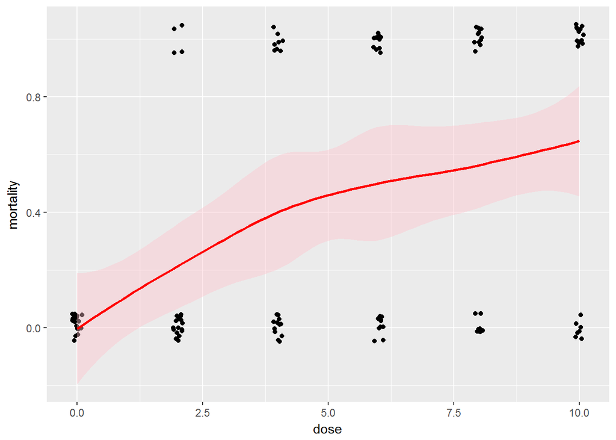

```r
# Often, we want to "look" at our data and trends in our data
# ggplot2 allows us to add trend lines to our data
# The defult lines are created using a technique called local regression
# However, we can specify different models, including GLMs
# During this exercise, we'll see how to plot a GLM

# Plot the data using jittered points and the default stat_smooth
ggplot(data = dfLong, aes(x = dose, y = mortality)) +
    geom_jitter(height = 0.05, width = 0.1) +
    stat_smooth(fill = 'pink', color = 'red')
```

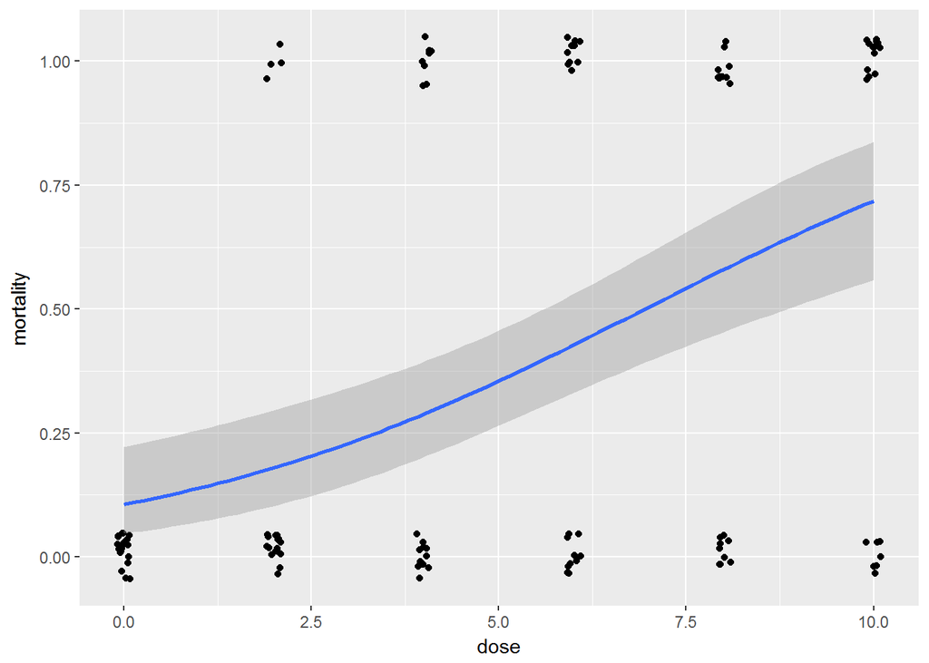

```r
# Plot the data using jittered points and the the glm stat_smooth
ggplot(data = dfLong, aes(x = dose, y = mortality)) +
    geom_jitter(height = 0.05, width = 0.1) +
    stat_smooth(method = 'glm',  method.args = list(family = "binomial"))
```

```r
# library(lmerTest)

df <- data.frame(dose=rep(rep(c(0, 2, 4, 6, 8, 10), each=20), times=3),
                 mortality=c(0, 0, 0, 0, 0, 0, 0, 0, 0, 0, 0, 0, 0, 0, 0, 0, 0, 0, 0, 0, 0, 1, 0, 0, 0, 0, 0, 0, 0, 0, 0, 0, 0, 0, 0, 0, 0, 0, 1, 1, 0, 0, 0, 1, 0, 0, 1, 0, 1, 0, 0, 1, 0, 1, 1, 0, 0, 1, 0, 1, 0, 1, 1, 1, 0, 0, 0, 1, 1, 0, 1, 1, 1, 1, 1, 0, 0, 1, 0, 0, 1, 1, 0, 0, 1, 0, 1, 1, 0, 1, 1, 1, 1, 1, 1, 1, 0, 1, 0, 1, 1, 0, 1, 0, 1, 1, 0, 1, 1, 1, 1, 1, 1, 1, 1, 1, 1, 0, 1, 1, 0, 0, 0, 0, 0, 0, 0, 0, 0, 0, 0, 0, 0, 0, 0, 0, 0, 0, 0, 0, 1, 0, 0, 0, 1, 1, 0, 0, 0, 0, 0, 0, 1, 0, 0, 0, 0, 0, 1, 0, 1, 1, 0, 1, 1, 1, 1, 0, 0, 1, 1, 0, 1, 0, 0, 1, 0, 1, 0, 1, 0, 0, 1, 0, 0, 1, 0, 0, 1, 0, 1, 0, 1, 1, 0, 1, 1, 0, 1, 0, 1, 1, 0, 0, 1, 1, 1, 1, 1, 1, 1, 0, 1, 1, 0, 1, 1, 0, 0, 0, 0, 1, 1, 1, 0, 1, 1, 1, 1, 1, 1, 0, 1, 1, 0, 0, 1, 1, 1, 0, 0, 0, 0, 0, 0, 0, 0, 0, 0, 0, 0, 0, 0, 0, 0, 0, 0, 0, 0, 0, 0, 0, 0, 0, 0, 0, 0, 0, 0, 1, 0, 0, 0, 0, 0, 0, 1, 1, 0, 0, 0, 0, 0, 1, 0, 0, 0, 1, 1, 1, 1, 1, 0, 0, 0, 0, 0, 0, 1, 1, 1, 0, 0, 1, 1, 0, 1, 1, 1, 0, 0, 0, 0, 0, 0, 1, 1, 1, 0, 0, 0, 1, 1, 1, 0, 1, 1, 1, 0, 1, 1, 1, 1, 1, 1, 1, 1, 0, 1, 1, 1, 1, 1, 1, 0, 1, 1, 1, 1, 1, 1, 1, 1, 0, 1, 1, 1, 1, 1, 1),
                 replicate=factor(rep(letters[1:3], each=120))
                 )
str(df)
```

```
## 'data.frame':    360 obs. of  3 variables:
##  $ dose     : num  0 0 0 0 0 0 0 0 0 0 ...
##  $ mortality: num  0 0 0 0 0 0 0 0 0 0 ...
##  $ replicate: Factor w/ 3 levels "a","b","c": 1 1 1 1 1 1 1 1 1 1 ...
```

```r
glmerOut <- lme4::glmer(mortality ~ dose + (1|replicate), family = 'binomial', data = df)
summary(glmerOut)
```

```
## Generalized linear mixed model fit by maximum likelihood (Laplace
##   Approximation) [glmerMod]
##  Family: binomial  ( logit )
## Formula: mortality ~ dose + (1 | replicate)
##    Data: df
##
##      AIC      BIC   logLik deviance df.resid
##    378.1    389.8   -186.0    372.1      357
##
## Scaled residuals:
##     Min      1Q  Median      3Q     Max
## -2.3484 -0.6875 -0.3031  0.6413  2.1907
##
## Random effects:
##  Groups    Name        Variance  Std.Dev.
##  replicate (Intercept) 6.658e-15 8.16e-08
## Number of obs: 360, groups:  replicate, 3
##
## Fixed effects:
##             Estimate Std. Error z value Pr(>|z|)
## (Intercept) -2.38736    0.27334  -8.734   <2e-16 ***
## dose         0.40948    0.04414   9.276   <2e-16 ***
## ---
## Signif. codes:  0 '***' 0.001 '**' 0.01 '*' 0.05 '.' 0.1 ' ' 1
##
## Correlation of Fixed Effects:
##      (Intr)
## dose -0.884
```

```r
# library(lmerTest)
# Fit the model and look at its summary
# modelOut <- lme4::glmer( cbind(Purchases, Pass) ~ friend + ranking + (1|city), data = allData, family = 'binomial')
# summary( modelOut)

# Compare outputs to a lmer model
# summary(lme4::lmer( Purchases/( Purchases + Pass) ~ friend + ranking + (1|city), data = allData))


# Run the code to see how to calculate odds ratios
# summary(modelOut)
# exp(fixef(modelOut)[2])
# exp(confint(modelOut)[3, ])


# Load lmerTest
# library(lmerTest)


userGroups <- data.frame(group=factor(rep(rep(LETTERS[1:4], each=10), times=2)),
                         webpage=factor(rep(c("old", "new"), each=40)),
                         clicks=c(0, 0, 0, 0, 0, 0, 2, 0, 0, 0, 1, 0, 0, 1, 1, 1, 2, 0, 1, 1, 0, 3, 2, 3, 1, 2, 4, 2, 1, 0, 2, 0, 1, 2, 0, 2, 1, 1, 2, 4, 2, 8, 1, 1, 1, 2, 1, 1, 0, 0, 3, 0, 1, 4, 1, 2, 0, 1, 1, 0, 0, 3, 2, 0, 3, 1, 2, 2, 0, 2, 3, 1, 3, 2, 4, 4, 2, 1, 5, 2)
                         )
str(userGroups)
```

```
## 'data.frame':    80 obs. of  3 variables:
##  $ group  : Factor w/ 4 levels "A","B","C","D": 1 1 1 1 1 1 1 1 1 1 ...
##  $ webpage: Factor w/ 2 levels "new","old": 2 2 2 2 2 2 2 2 2 2 ...
##  $ clicks : num  0 0 0 0 0 0 2 0 0 0 ...
```

```r
# Fit a Poisson glmer
summary( lme4::glmer(clicks ~ webpage + (1|group), family = 'poisson', data = userGroups))
```

```
## Generalized linear mixed model fit by maximum likelihood (Laplace
##   Approximation) [glmerMod]
##  Family: poisson  ( log )
## Formula: clicks ~ webpage + (1 | group)
##    Data: userGroups
##
##      AIC      BIC   logLik deviance df.resid
##    255.5    262.6   -124.7    249.5       77
##
## Scaled residuals:
##     Min      1Q  Median      3Q     Max
## -1.3999 -0.9104 -0.2340  0.4978  5.6126
##
## Random effects:
##  Groups Name        Variance Std.Dev.
##  group  (Intercept) 0.07093  0.2663
## Number of obs: 80, groups:  group, 4
##
## Fixed effects:
##             Estimate Std. Error z value Pr(>|z|)
## (Intercept)   0.5524     0.1797   3.074  0.00211 **
## webpageold   -0.5155     0.1920  -2.685  0.00726 **
## ---
## Signif. codes:  0 '***' 0.001 '**' 0.01 '*' 0.05 '.' 0.1 ' ' 1
##
## Correlation of Fixed Effects:
##            (Intr)
## webpageold -0.400
```

```r
# library(lmerTest)


rawIL <- read.csv("./RInputFiles/ILData.csv")
ILdata <- rawIL
str(ILdata)
```

```
## 'data.frame':    1808 obs. of  4 variables:
##  $ age   : Factor w/ 4 levels "15_19","20_24",..: 1 1 1 1 1 1 1 1 1 1 ...
##  $ year  : int  0 0 0 0 0 0 0 0 0 0 ...
##  $ county: Factor w/ 47 levels "ALEXANDER","BROWN",..: 1 2 3 4 5 6 7 8 9 10 ...
##  $ count : int  0 0 0 5 0 7 0 4 0 12 ...
```

```r
# Age goes before year
modelOut <- lme4::glmer(count ~ age + year + (year|county), family = 'poisson', data = ILdata)
summary(modelOut)
```

```
## Generalized linear mixed model fit by maximum likelihood (Laplace
##   Approximation) [glmerMod]
##  Family: poisson  ( log )
## Formula: count ~ age + year + (year | county)
##    Data: ILdata
##
##      AIC      BIC   logLik deviance df.resid
##   3215.6   3259.6  -1599.8   3199.6     1800
##
## Scaled residuals:
##     Min      1Q  Median      3Q     Max
## -2.4511 -0.0151 -0.0056 -0.0022  4.0053
##
## Random effects:
##  Groups Name        Variance Std.Dev. Corr
##  county (Intercept) 129.9459 11.3994
##         year          0.0648  0.2546  -1.00
## Number of obs: 1808, groups:  county, 47
##
## Fixed effects:
##              Estimate Std. Error z value Pr(>|z|)
## (Intercept) -10.76258    2.13022  -5.052 4.36e-07 ***
## age20_24     -0.04152    0.03690  -1.125    0.261
## age25_29     -1.16262    0.05290 -21.976  < 2e-16 ***
## age30_34     -2.28278    0.08487 -26.898  < 2e-16 ***
## year          0.32708    0.25422   1.287    0.198
## ---
## Signif. codes:  0 '***' 0.001 '**' 0.01 '*' 0.05 '.' 0.1 ' ' 1
##
## Correlation of Fixed Effects:
##          (Intr) a20_24 a25_29 a30_34
## age20_24 -0.008
## age25_29 -0.006  0.341
## age30_34 -0.004  0.213  0.148
## year     -0.764  0.000  0.000  0.000
## convergence code: 0
## Model failed to converge with max|grad| = 0.00144074 (tol = 0.001, component 1)
```

```r
# Extract out fixed effects
lme4::fixef(modelOut)
```

```
##  (Intercept)     age20_24     age25_29     age30_34         year
## -10.76258497  -0.04151848  -1.16262225  -2.28277972   0.32708039
```

```r
# Extract out random effects
lme4::ranef(modelOut)
```

```
## $county
##            (Intercept)         year
## ALEXANDER   -0.2847724  0.006331741
## BROWN       -0.2847724  0.006331741
## CALHOUN     -0.2847724  0.006331741
## CARROLL     12.2418514 -0.260423999
## CASS        -0.2847724  0.006331741
## CLARK       12.2137668 -0.268553354
## CLAY        -0.2847724  0.006331741
## CRAWFORD    12.5037407 -0.265752695
## CUMBERLAND  -0.2847724  0.006331741
## DE WITT     12.7456078 -0.277675211
## DOUGLAS     13.0751590 -0.306329903
## EDGAR       12.3642794 -0.283606045
## EDWARDS     -0.2847724  0.006331741
## FAYETTE     12.8094530 -0.273060474
## FORD        -0.2847724  0.006331741
## GALLATIN    -0.2847724  0.006331741
## GREENE      -0.2847724  0.006331741
## HAMILTON    -0.2847724  0.006331741
## HANCOCK     12.8581265 -0.305650287
## HARDIN      -0.2847724  0.006331741
## HENDERSON   -0.2847724  0.006331741
## IROQUOIS    13.1616741 -0.311372907
## JASPER      -0.2847724  0.006331741
## JERSEY      12.9202747 -0.272284048
## JO DAVIESS  12.7409389 -0.289747791
## JOHNSON     -0.2847724  0.006331741
## LAWRENCE    12.3713561 -0.268571236
## MARSHALL    -0.2847724  0.006331741
## MASON       -0.2847724  0.006331741
## MENARD      -0.2180916  0.004849989
## MERCER      12.7534193 -0.271678572
## MOULTRIE    -0.2180916  0.004849989
## PIATT       12.5653132 -0.296687752
## PIKE        12.5310614 -0.259211299
## POPE        -0.2180916  0.004849989
## PULASKI     -0.2180916  0.004849989
## PUTNAM      -0.2180916  0.004849989
## RICHLAND    12.0350865 -0.273928951
## SCHUYLER    -0.2180916  0.004849989
## SCOTT       -0.2180916  0.004849989
## SHELBY      12.5183293 -0.283472292
## STARK       -0.2180916  0.004849989
## UNION       13.1465272 -0.308673332
## WABASH      -0.2180916  0.004849989
## WASHINGTON  -0.2180916  0.004849989
## WAYNE       12.1148896 -0.253234752
## WHITE       -0.2180916  0.004849989
```

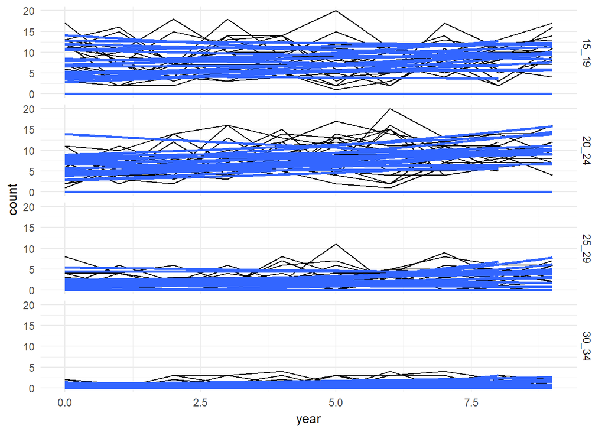

```r
# Run code to see one method for plotting the data
ggplot(data = ILdata, aes(x = year, y = count, group = county)) +
    geom_line() +
    facet_grid(age ~ . ) +
    stat_smooth( method = 'glm',
                method.args = list( family = "poisson"), se = FALSE,
                alpha = 0.5) +
    theme_minimal()
```

Chapter 4 - Repeated Measures

An introduction to repeated measures:

- Sampling the same thing over time is a repeated measure, a specific example of a mixed effects model
  - Follow the same individual through time - cohorts allow for controlling for individuality
  - The paired t-test is often used for assessing a repeated measures dataset - t.test(x1, x2, paired=TRUE) # x1 and x2 need to be the same length and each element needs to be the same individual
- Repeated measures ANOVA is a conceptual extension of the paired t-test - are the means constant over time
  - anova(lmer(y ~ time + (1|individual)))
  - Can be used with glmer() also
  - Note that degrees of freedom is still an open question - different packages calculate this differently

Sleep study:

- Applying LMER to the sleep study dataset - impact of drugs on sleep patterns for 10 patients followed over time
  - This is the classic “Student” dataset due to Guinness at the time not allowing its employees to publish
  - Ho will be that the amount of sleep does not vary with the treatments
  - Modeling will be done using a linear mixed model
- Modeling approach - iteratively;
  - EDA
  - Simple regression
  - Model of interest
  - Extract information from model
  - Visualize final data

Hate in NY state?

- Change in rate of hate crimes over time by county - available from data.gov for 2010-2016
- Level of technical details in reporting should vary significantly by audience - blend data in to story for wider audiences, while being reporducible/technical for a scientifc audience

Wrap up:

- Hiearchical data, mixed effects models, case studies
- Start with the LME4 documentation for additional explorations and details

Example code includes:

```r
y <- c(0.23, 2.735, -0.038, 6.327, -0.643, 1.69, -1.378, -1.228, -0.252, 2.014, -0.073, 6.101, 0.213, 3.127, -0.29, 8.395, -0.33, 2.735, 0.223, 1.301)
treat <- rep(c("before", "after"), times=10)
x <- rep(letters[1:10], each=2)

# Run a standard, non-paired t-test
t.test(y[treat == "before"], y[treat == "after"], paired = FALSE)
```

```
##
##  Welch Two Sample t-test
##
## data:  y[treat == "before"] and y[treat == "after"]
## t = -3.9043, df = 9.5409, p-value = 0.003215
## alternative hypothesis: true difference in means is not equal to 0
## 95 percent confidence interval:
##  -5.594744 -1.512256
## sample estimates:
## mean of x mean of y
##   -0.2338    3.3197
```

```r
# Run a standard, paired t-test
t.test(y[treat == "before"], y[treat == "after"], paired = TRUE)
```

```
##
##  Paired t-test
##
## data:  y[treat == "before"] and y[treat == "after"]
## t = -4.2235, df = 9, p-value = 0.002228
## alternative hypothesis: true difference in means is not equal to 0
## 95 percent confidence interval:
##  -5.456791 -1.650209
## sample estimates:
## mean of the differences
##                 -3.5535
```

```r
library(lmerTest)
library(lme4)

# Run the paired-test like before
t.test(y[treat == "before"], y[treat == "after"], paired = TRUE)
```

```
##
##  Paired t-test
##
## data:  y[treat == "before"] and y[treat == "after"]
## t = -4.2235, df = 9, p-value = 0.002228
## alternative hypothesis: true difference in means is not equal to 0
## 95 percent confidence interval:
##  -5.456791 -1.650209
## sample estimates:
## mean of the differences
##                 -3.5535
```

```r
# Run a repeated-measures ANOVA
anova(lmer( y ~ treat + (1|x)))
```

```
## Type III Analysis of Variance Table with Satterthwaite's method
##       Sum Sq Mean Sq NumDF DenDF F value   Pr(>F)
## treat 63.137  63.137     1     9  17.838 0.002228 **
## ---
## Signif. codes:  0 '***' 0.001 '**' 0.01 '*' 0.05 '.' 0.1 ' ' 1
```

```r
data(sleepstudy, package="lme4")
str(sleepstudy)
```

```
## 'data.frame':    180 obs. of  3 variables:
##  $ Reaction: num  250 259 251 321 357 ...
##  $ Days    : num  0 1 2 3 4 5 6 7 8 9 ...
##  $ Subject : Factor w/ 18 levels "308","309","310",..: 1 1 1 1 1 1 1 1 1 1 ...
```

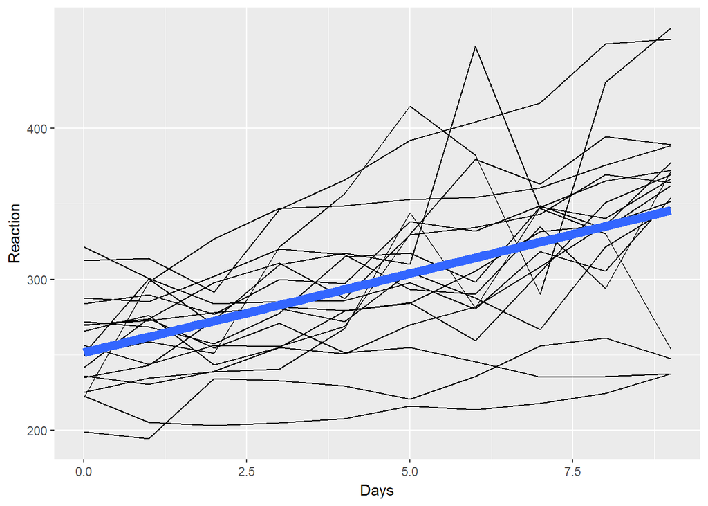

```r
# Plot the data
ggplot(data = sleepstudy) +
    geom_line(aes(x = Days, y = Reaction, group = Subject)) +
    stat_smooth(aes(x = Days, y = Reaction), method = 'lm', size = 3, se = FALSE)
```

```r
# Build a lm
lm( Reaction ~ Days, data = sleepstudy)
```

```
##
## Call:
## lm(formula = Reaction ~ Days, data = sleepstudy)
##
## Coefficients:
## (Intercept)         Days
##      251.41        10.47
```

```r
# Build a lmer
(lmerOut <- lmer( Reaction ~ Days + (1|Subject), data = sleepstudy))
```

```
## Linear mixed model fit by REML ['lmerModLmerTest']
## Formula: Reaction ~ Days + (1 | Subject)
##    Data: sleepstudy
## REML criterion at convergence: 1786.465
## Random effects:
##  Groups   Name        Std.Dev.
##  Subject  (Intercept) 37.12
##  Residual             30.99
## Number of obs: 180, groups:  Subject, 18
## Fixed Effects:
## (Intercept)         Days
##      251.41        10.47
```

```r
# The lmer model you built during the previous exercise has been saved as lmerOut
# During this exercise, you will examine the effects of drug type using both an ANOVA framework and a regression framework

# Run an anova
anova(lmerOut)
```

```
## Type III Analysis of Variance Table with Satterthwaite's method
##      Sum Sq Mean Sq NumDF DenDF F value    Pr(>F)
## Days 162703  162703     1   161   169.4 < 2.2e-16 ***
## ---
## Signif. codes:  0 '***' 0.001 '**' 0.01 '*' 0.05 '.' 0.1 ' ' 1
```

```r
# Look at the regression coefficients
summary(lmerOut)
```

```
## Linear mixed model fit by REML. t-tests use Satterthwaite's method [
## lmerModLmerTest]
## Formula: Reaction ~ Days + (1 | Subject)
##    Data: sleepstudy
##
## REML criterion at convergence: 1786.5
##
## Scaled residuals:
##     Min      1Q  Median      3Q     Max
## -3.2257 -0.5529  0.0109  0.5188  4.2506
##
## Random effects:
##  Groups   Name        Variance Std.Dev.
##  Subject  (Intercept) 1378.2   37.12
##  Residual              960.5   30.99
## Number of obs: 180, groups:  Subject, 18
##
## Fixed effects:
##             Estimate Std. Error       df t value Pr(>|t|)
## (Intercept) 251.4051     9.7467  22.8100   25.79   <2e-16 ***
## Days         10.4673     0.8042 161.0000   13.02   <2e-16 ***
## ---
## Signif. codes:  0 '***' 0.001 '**' 0.01 '*' 0.05 '.' 0.1 ' ' 1
##
## Correlation of Fixed Effects:
##      (Intr)
## Days -0.371
```

```r
# Read in NY hate data
rawHate <- read.csv("./RInputFiles/hateNY.csv")
hate <- rawHate
str(hate)
```

```
## 'data.frame':    233 obs. of  4 variables:
##  $ Year          : int  2010 2011 2012 2013 2014 2015 2016 2013 2010 2011 ...
##  $ County        : Factor w/ 59 levels "Albany","Allegany",..: 1 1 1 1 1 1 1 2 3 3 ...
##  $ TotalIncidents: int  13 7 5 3 3 3 3 1 22 11 ...
##  $ Year2         : int  0 1 2 3 4 5 6 3 0 1 ...
```

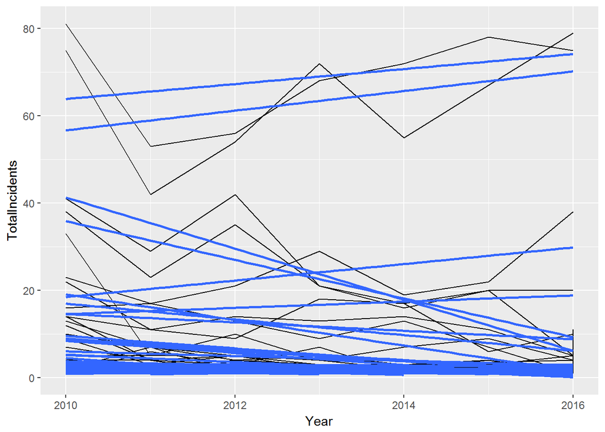

```r
ggplot( data = hate, aes(x = Year, y = TotalIncidents, group = County)) +
    geom_line() +
    geom_smooth(method = 'lm', se = FALSE)
```

```r
# During this exercise, you will build a glmer
# Because most of the incidents are small count values, use a Poisson (R function family poisson) error term
# First, build a model using the actually year (variable Year, such as 2006, 2007, etc) - this model will fail
# Second, build a model using the rescaled year (variable Year2, such as 0, 1, 2, etc)
# This demonstrates the importance of considering where the intercept is located when building regression models
# Recall that a variable x can be both a fixed and random effect in a lmer() or glmer(): for example lmer(y ~ x + (x| group) demonstrates this syntax

# glmer with raw Year
glmer(TotalIncidents ~ Year + (Year|County), data = hate, family = "poisson")
```

```
## Generalized linear mixed model fit by maximum likelihood (Laplace
##   Approximation) [glmerMod]
##  Family: poisson  ( log )
## Formula: TotalIncidents ~ Year + (Year | County)
##    Data: hate
##       AIC       BIC    logLik  deviance  df.resid
## 1165.2746 1182.5298 -577.6373 1155.2746       228
## Random effects:
##  Groups Name        Std.Dev. Corr
##  County (Intercept) 217.8915
##         Year          0.1084 -1.00
## Number of obs: 233, groups:  County, 59
## Fixed Effects:
## (Intercept)         Year
##    295.4814      -0.1464
## convergence code 0; 3 optimizer warnings; 0 lme4 warnings
```

```r
# glmer with scaled Year, Year2
glmerOut <- glmer(TotalIncidents ~ Year2 + (Year2|County), data = hate, family = "poisson")
summary(glmerOut)
```

```
## Generalized linear mixed model fit by maximum likelihood (Laplace
##   Approximation) [glmerMod]
##  Family: poisson  ( log )
## Formula: TotalIncidents ~ Year2 + (Year2 | County)
##    Data: hate
##
##      AIC      BIC   logLik deviance df.resid
##   1165.3   1182.5   -577.6   1155.3      228
##
## Scaled residuals:
##     Min      1Q  Median      3Q     Max
## -2.5434 -0.4864 -0.1562  0.3319  3.1939
##
## Random effects:
##  Groups Name        Variance Std.Dev. Corr
##  County (Intercept) 1.16291  1.0784
##         Year2       0.01175  0.1084   0.02
## Number of obs: 233, groups:  County, 59
##
## Fixed effects:
##             Estimate Std. Error z value Pr(>|z|)
## (Intercept)  1.27952    0.16600   7.708 1.28e-14 ***
## Year2       -0.14622    0.03324  -4.398 1.09e-05 ***
## ---
## Signif. codes:  0 '***' 0.001 '**' 0.01 '*' 0.05 '.' 0.1 ' ' 1
##
## Correlation of Fixed Effects:
##       (Intr)
## Year2 -0.338
```

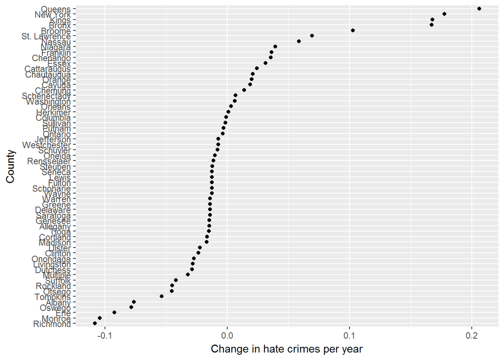

```r
# Extract and manipulate data
countyTrend <- ranef(glmerOut)$County
countyTrend$county <- factor(row.names(countyTrend), levels =row.names(countyTrend)[order(countyTrend$Year2)])

# Plot results
ggplot(data = countyTrend, aes(x = county, y = Year2)) + geom_point() +
    coord_flip() +
    ylab("Change in hate crimes per year")  +
    xlab("County")
```

### *Forecasting Product Demand in R*

Chapter 1 - Forecasting Demand with Time Series

Loading data in to an xts object:

- The xts object will be the buidling block for the course - extensible time series (xts) is an extension of the zoo package - basically, a time index attached to the data matrix
- Can create dates using dates=seq(as.Date(“MM-DD-YYYY”), length=, by=“weeks”) # to create weekly data
  - xts(myData, order.by=dates) # will create an XTS using dates as the index

ARIMA Time Series 101:

- AR - AutoRegressive (lags help to determine today’s values - “long memory models”)
- MA - Moving Average (shocks/errors help to determine today’s shocks/errors - “short memory models” due to dissipation)
- I - Integrated (does the data have a dependency across time, and how long does it last) - make the time series stationary
  - Stationarity is the idea that effects disipate over time - today has more impact on tomorrow than on time periods in the future
  - Differencing (monthly, seasonal, etc.) the data can be a useful approach for data with stationarity
- Begin by creating training dataset and valiadation training dataset
- The auto.arima() function tries to estimate the best ARIMA for a given data series
  - ARIMA(p, d, q) is ARIMA(AR, Differencing, MA)

Forecasting and Evaluating:

- Can use the ARIMA data to forecast the data forward - extrapolating the signal (forecasting) and estimating the amount of noise (error or CI)
- The forecast() function in R simplifies the process - forecast(myModel, h=) which will forecast forward h time periods
- Two common error measurements include MAE (mean average error) and MAPE (mean average percentage error)
  - MAPE is better at putting things on a common scale

Example code includes:

```r
# Read in beverages data
rawBev <- read.csv("./RInputFiles/Bev.csv")
bev <- rawBev
str(bev)
```

```
## 'data.frame':    176 obs. of  14 variables:
##  $ M.hi.p  : num  59.2 56.3 56.3 49.3 61.3 ...
##  $ M.lo.p  : num  29.2 26.3 26.2 26.1 25.9 ...
##  $ MET.hi.p: num  63.7 60.3 60.8 55.1 65.1 ...
##  $ MET.lo.p: num  26 25.5 25.7 26.5 25.7 ...
##  $ MET.sp.p: num  50.1 48.8 48.6 47.7 50.8 ...
##  $ SEC.hi.p: num  58.6 54.6 57.9 49.7 63.7 ...
##  $ SEC.lo.p: num  29.2 26.3 26.2 26.1 25.9 ...
##  $ M.hi    : int  458 477 539 687 389 399 392 417 568 583 ...
##  $ M.lo    : int  1455 1756 2296 3240 2252 1901 1939 1999 1798 1558 ...
##  $ MET.hi  : int  2037 1700 1747 2371 1741 2072 2353 2909 3204 2395 ...
##  $ MET.lo  : int  3437 3436 3304 3864 3406 3418 3553 3376 3233 3262 ...
##  $ MET.sp  : int  468 464 490 657 439 453 423 408 501 481 ...
##  $ SEC.hi  : int  156 151 178 217 141 149 134 148 195 170 ...
##  $ SEC.lo  : int  544 624 611 646 624 610 623 599 551 539 ...
```

```r
# Load xts package
library(xts)
```

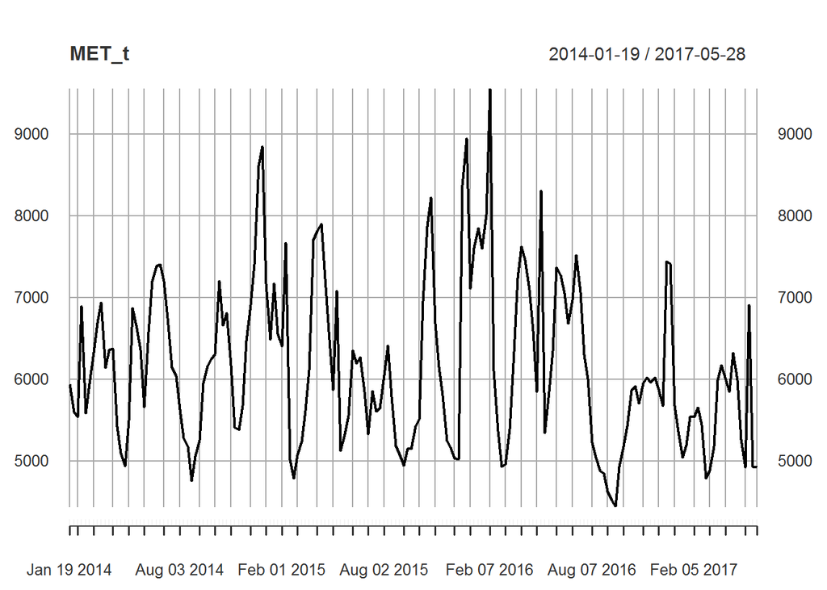

```r
library(forecast)


# Create the dates object as an index for your xts object
dates <- seq(as.Date("2014-01-19"), length = 176, by = "weeks")

# Create an xts object called bev_xts
bev_xts <- xts(bev, order.by = dates)


# Create the individual region sales as their own objects
MET_hi <- bev_xts[,"MET.hi"]
MET_lo <- bev_xts[,"MET.lo"]
MET_sp <- bev_xts[,"MET.sp"]

# Sum the region sales together
MET_t <- MET_hi + MET_lo + MET_sp

# Plot the metropolitan region total sales
plot(MET_t)
```

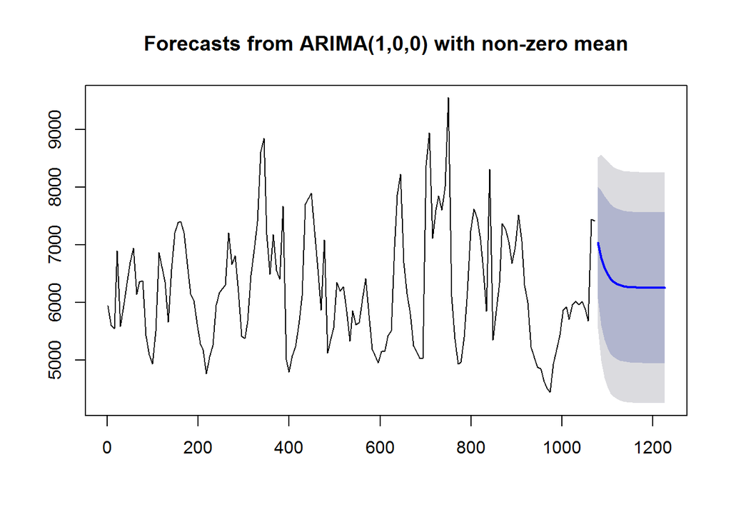

```r
# Split the data into training and validation
MET_t_train <- MET_t[index(MET_t) < "2017-01-01"]
MET_t_valid <- MET_t[index(MET_t) >= "2017-01-01"]

# Use auto.arima() function for metropolitan sales
MET_t_model <- auto.arima(MET_t_train)


# Forecast the first 22 weeks of 2017
forecast_MET_t <- forecast(MET_t_model, h = 22)

# Plot this forecast #
plot(forecast_MET_t)
```

```r
# Convert to numeric for ease
for_MET_t <- as.numeric(forecast_MET_t$mean)
v_MET_t <- as.numeric(MET_t_valid)

# Calculate the MAE
MAE <- mean(abs(for_MET_t - v_MET_t))

# Calculate the MAPE
MAPE <- 100*mean(abs(for_MET_t - v_MET_t)/v_MET_t)

# Print to see how good your forecast is!
print(MAE)
```

```
## [1] 898.8403
```

```r
print(MAPE)
```

```
## [1] 17.10332
```

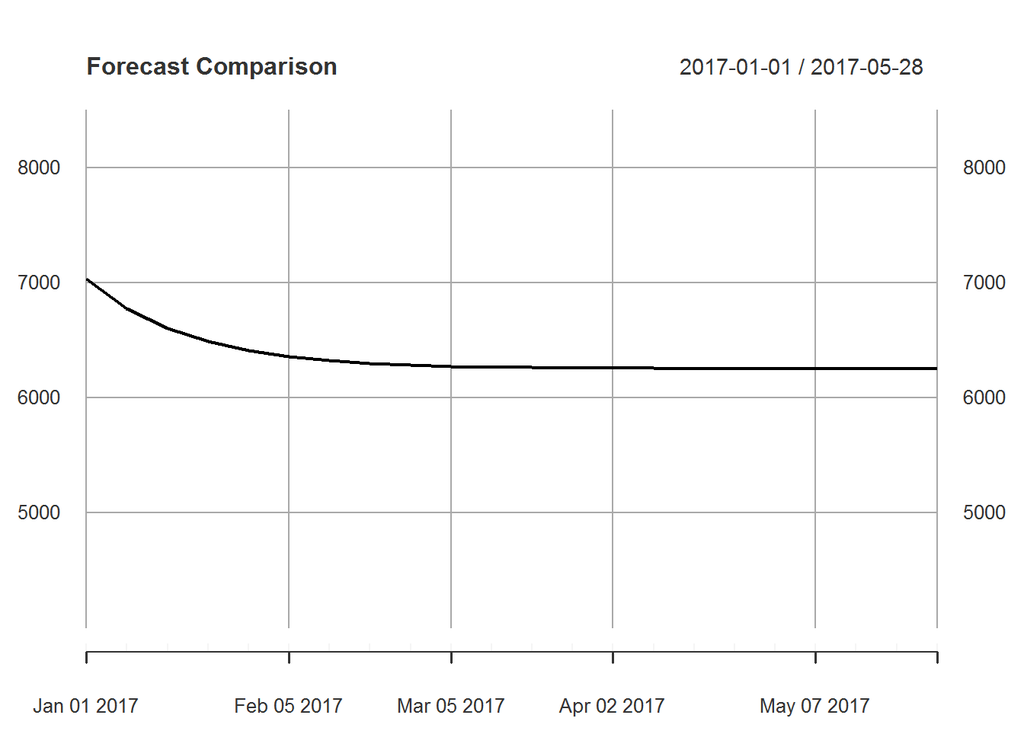

```r
# Convert your forecast to an xts object
for_dates <- seq(as.Date("2017-01-01"), length = 22, by = "weeks")
for_MET_t_xts <- xts(forecast_MET_t$mean, order.by = for_dates)

# Plot the validation data set
plot(for_MET_t_xts, main = 'Forecast Comparison', ylim = c(4000, 8500))
```

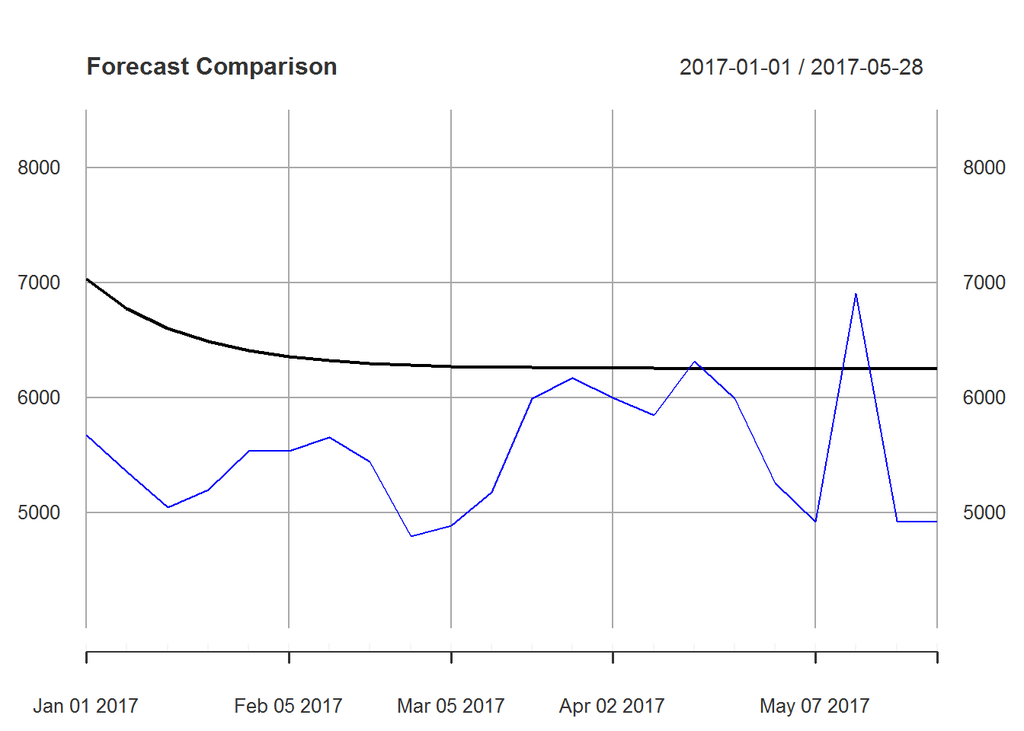

```r
# Overlay the forecast of 2017
lines(MET_t_valid, col = "blue")
```

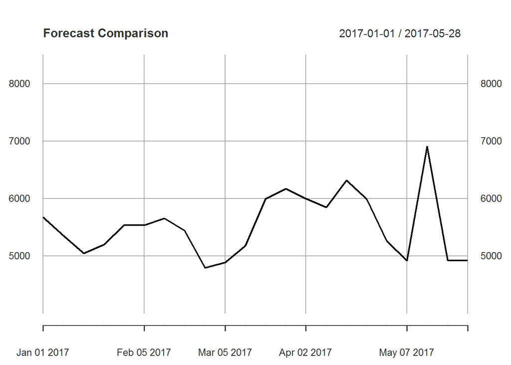

```r
# Plot the validation data set
plot(MET_t_valid, main = 'Forecast Comparison', ylim = c(4000, 8500))
```

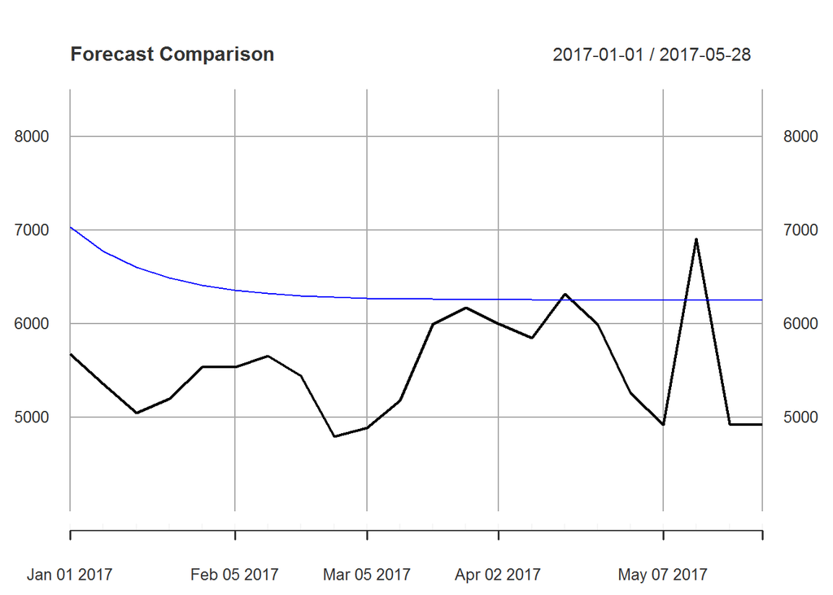

```r
# Overlay the forecast of 2017
lines(for_MET_t_xts, col = "blue")
```

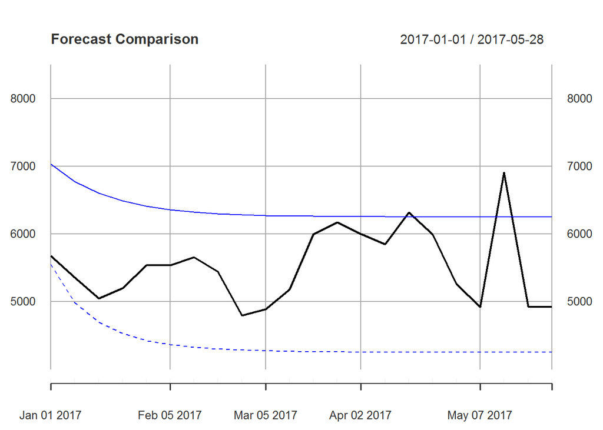

```r
# Convert the limits to xts objects
lower <- xts(forecast_MET_t$lower[, 2], order.by = for_dates)
upper <- xts(forecast_MET_t$upper[, 2], order.by = for_dates)

# Adding confidence intervals of forecast to plot
lines(lower, col = "blue", lty = "dashed")
```

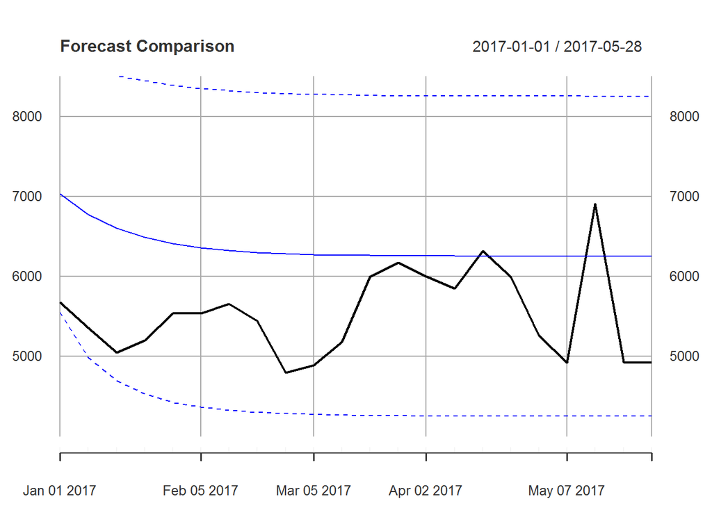

```r
lines(upper, col = "blue", lty = "dashed")
```

Chapter 2 - Components of Demand

Price elasticity:

- Price is one of the obvious factors that impacts demand, with the relationship called price elasticity (% dDemand / % dPrice)
  - Elastic goods have elasticity > 1, meaning demand changes more quickly (percentage wise) than price
  - Inelastic goods have elasticity < 1, for example gasoline
  - Unit elastic goods have elasticity = 1, meaning that X% increase in price drives X% decrease in demand
  - Linear regression can be employed to estimate the elasticity for a given product - the log-log transform helps get the % vs % coefficients

Seasonal/holiday/promotional effects:

- Seasonal products are common - can be bought any time of the year, though certain seasons have higher demand (holidays are a common example)
- Promotions are attempts by companies to influence demand
- Linear regression can help determine relationships between demand and many other factors
  - If an xts vector has been created for key dates, can merge(train, holiday, fill=0) and the holiday column will be 0 wherever there is no match to holiday

Forecasting with regression:

- Forecasting with time series is straightforward due to the lag nature of the models - tomorrow forecasts today and today forecasts tomorrow and etc.
- Forecasting with regression can be more tricky, particularly since we need the future inputs (such as price) in order to predict the future demand
  - Even when there are contractually fixed prices, promotions can effectively create a de facto price change anyways
- Need to have the same column names in the test/validation dataset as were used in the modeling
  - Then, can use predict(myModel, myData)
  - May need to exponentiate in case the data are currently on the log scale rather than the absolute scale